# Conflict and coexistence between people and the world’s largest scavenger bird

Juan Sebastián Restrepo-Cardona, Orlando Acevedo-Charry, Rubén Pineida, Sebastián Kohn, Diego Bamontes, Fabricio Narváez, Paul Monar-Barragán, & Vanessa Hull (elaborated by OAC)

19 November 2026

# 1 Read me

This paper aims to understand human-vulture perception of conflict regarding the role of the Andean Condor (*Vultur gryphus*) as a potential predator. The specific aims were:

- To examine local perceptions of the negative impacts of condors as potential predator of livestock, and analyze how these perceptions relate to socio-demographic and psychological factors, livestock management practices, and experience or attitude by farmers.
- To examine local perceptions of the condor’s contributions to farmers: negative due to perception of harmfulness, positive due to perceived benefits and values, or a combination of both, and analyze how these perceptions relate to socio-demographic and psychological factors, livestock management practices, and experience or attitude by farmers (including perception of attacking livestock).
- To assess whether field observations support the reported perceptions of condor-related damage
- To explore how people’s perceptions of the costs and benefits associated with condors, and the previous exposure to environmental workshops, influence coexistence-based conservation behaviors (evaluate conservation behaviors).

A further work will assess attitudes (feelings, disappear, population preference change) as response variables, but in this study we focused on perceptions as response variables.

## 1.1 Packages

Load the packages used

```r
library(tidyverse) # organize data
library(MetBrewer) # cool palette of colors
library(patchwork) # organize figures in multipanels
library(MASS) # ordinal GLM
library(nnet) # multinomial GLM
library(logistf) # Firth's Bias-Reduced Logistic Regression (penalized-likelihood)
```

## 1.2 Useful functions

```r
# Predict from parameters
predict_from_params <- function(params, newdata, model) {
  # number of beta coefficients
  nb <- length(model$coefficients)

  # replace coefficients
  model$coefficients <- params[1:nb]

  # replace thresholds
  model$zeta <- params[(nb+1):length(params)]

  predict(model, newdata, type = "probs")
}

# Predicting from multinomial parameters
predict_multinom_params <- function(par, newdata, model) {

  # number of non-reference categories and predictors
  K <- length(model$lev) - 1
  P <- length(model$coefnames)

  # reshape parameter vector into matrix
  par_mat <- matrix(par, nrow = K, ncol = P, byrow = TRUE)
  rownames(par_mat) <- model$lev[-1] # all but the reference
  colnames(par_mat) <- model$coefnames

  # extract RHS of formula (no response)
  rhs <- delete.response(terms(model))

  # model matrix for newdata
  X <- model.matrix(rhs, newdata)

  # linear predictors for each non-reference category
  eta <- X %*% t(par_mat)   # dim: [rows × K]

  # add reference category (0)
  eta_full <- cbind(0, eta)

  # softmax to convert to probabilities
  probs <- exp(eta_full) / rowSums(exp(eta_full))

  colnames(probs) <- model$lev

  return(probs)
}

# Inverted logit to convert linear predictors to probabilities
invlogit <- function(x) exp(x) / (1 + exp(x))

# AICc comparison for Firth's bias-reduced logistic regression
AICc_logistf <- function(model) {
  ll <- model$loglik  # penalized log-likelihood (implemented in logistf)
  K  <- length(model$coef)  # number of parameters
  n  <- model$n  # sample size

  AIC  <- -2 * ll + 2 * K # AIC formula
  AICc <- AIC + (2 * K * (K + 1)) / (n - K - 1) # small sample correction

  return(data.frame(AIC = AIC, AICc = AICc, K = K))
}

# Make predictions from logistic regression with penalized likelihood
make_pred_df <- function(model, newdata, xvar) {

  pred_lp <- predict(model, newdata, type = "link", se.fit = TRUE)

  newdata$lp      <- pred_lp$fit
  newdata$lp_low  <- pred_lp$fit - 1.96 * pred_lp$se.fit
  newdata$lp_high <- pred_lp$fit + 1.96 * pred_lp$se.fit

  invlogit <- function(x) exp(x) / (1 + exp(x))

  newdata$pred      <- invlogit(newdata$lp)
  newdata$pred_low  <- invlogit(newdata$lp_low)
  newdata$pred_high <- invlogit(newdata$lp_high)

  newdata$xvar <- newdata[[xvar]]

  return(newdata)
}
```

# 2 Data loading and exploratory analyzes

```r
perceptions <- read_csv("data_condor/perceptions_data.csv")
# correcting the data
perceptions[32,c(17:18)] <- NA

interactions <- read_csv("data_condor/interactions_data.csv")
str(perceptions)
```

```
## spc_tbl_ [58 × 38] (S3: spec_tbl_df/tbl_df/tbl/data.frame)
##  $ Subject                                                                                                                                                        : num [1:58] 1 2 3 4 5 6 7 8 9 10 ...
##  $ Paddock site                                                                                                                                                   : num [1:58] 0 0 0 0 0 0 0 0 0 0 ...
##  $ Gender                                                                                                                                                         : num [1:58] 0 0 0 0 0 1 1 0 0 1 ...
##  $ Age                                                                                                                                                            : num [1:58] 40 48 60 56 43 48 63 25 80 44 ...
##  $ Education level                                                                                                                                                : num [1:58] 2 1 1 2 1 2 1 2 0 1 ...
##  $ Time of residence                                                                                                                                              : num [1:58] 22 20 2 56 43 20 4 1 80 44 ...
##  $ Occupation                                                                                                                                                     : num [1:58] 0 0 0 0 1 0 1 0 1 1 ...
##  $ Type of livestock                                                                                                                                              : num [1:58] 5 5 2 2 2 2 0 2 4 0 ...
##  $ Cattle                                                                                                                                                         : num [1:58] 400 300 60 25 40 25 5 200 9 10 ...
##  $ Horse                                                                                                                                                          : num [1:58] 300 100 10 19 10 6 NA 10 1 NA ...
##  $ Sheep                                                                                                                                                          : num [1:58] 600 300 NA NA NA NA NA NA NA NA ...
##  $ Lama                                                                                                                                                           : num [1:58] NA NA NA NA NA NA NA NA 4 NA ...
##  $ Type of cattle production                                                                                                                                      : num [1:58] 3 4 1 4 5 4 1 1 1 1 ...
##  $ Do you think condors attack living livestock?                                                                                                                  : num [1:58] 3 1 1 3 3 3 2 0 2 1 ...
##  $ Have you suffered losses of livestock due to attacks by condors?                                                                                               : num [1:58] 0 1 1 1 0 0 1 1 0 1 ...
##  $ Have you ever seen condors attacking living livestock?                                                                                                         : num [1:58] 0 1 1 1 1 1 1 1 1 1 ...
##  $ If you have suffered the loss of livestock due to attacks by condors in the last 5 years, do you consider these losses acceptable, unacceptable, or negligible?: num [1:58] 0 NA NA NA 2 1 NA NA 0 NA ...
##  $ If you have suffered an attack in the last 5 years, have you reported it to the provincial authority?                                                          : num [1:58] 1 NA NA NA 1 1 NA NA 0 NA ...
##  $ Do you think the response of the authority was positive?                                                                                                       : num [1:58] NA NA NA NA NA NA NA NA 1 NA ...
##  $ Do you think that the authority's response satisfies the farmers who have suffered an attack?                                                                  : num [1:58] NA NA NA NA NA NA NA NA 1 NA ...
##  $ Could you indicate if the Andean condor is beneficial and/or harmful to you?                                                                                   : num [1:58] 2 2 0 2 0 2 0 1 2 2 ...
##  $ Why is the species harmful?                                                                                                                                    : chr [1:58] "Livestock predation" "Livestock predation" "Livestock predation" "Livestock predation" ...
##  $ Why is the species beneficial?                                                                                                                                 : chr [1:58] "Scavenging" "National emblem" NA "Scavenging, tourist attraction" ...
##  $ What do you think could be a solution to prevent Andean condors from attacking livestock?                                                                      : num [1:58] 1 2 0 1 1 1 0 1 1 1 ...
##  $ Killing condors is necessary to prevent further damage?                                                                                                        : num [1:58] 4 3 0 3 3 3 0 3 2 3 ...
```

[output cut: 55 more lines]

```r
str(interactions)
```

```
## spc_tbl_ [50 × 33] (S3: spec_tbl_df/tbl_df/tbl/data.frame)
##  $ Site              : chr [1:50] "Antisana Chakana" "Antisana Chakana" "Antisana Chakana" "Antisana Chakana" ...
##  $ Date (DD/MM/YY)   : chr [1:50] "3/26/25" "3/28/25" "4/21/25" "5/7/25" ...
##  $ Hour              : 'hms' num [1:50] 07:46:00 08:05:00 07:41:00 05:20:00 ...
##   ..- attr(*, "units")= chr "secs"
##  $ N_Cattle          : num [1:50] 67 73 82 70 97 105 91 92 106 106 ...
##  $ N_Horses          : num [1:50] 14 12 0 9 10 0 0 0 0 0 ...
##  $ N_Sheeps          : num [1:50] 0 0 0 0 0 0 0 0 0 0 ...
##  $ N_Lamas           : num [1:50] 0 0 0 0 2 0 0 0 0 0 ...
##  $ N_neoCattle       : num [1:50] 0 0 0 0 0 0 0 0 0 0 ...
##  $ N_calvesCattle    : num [1:50] 1 9 10 5 6 20 0 4 15 15 ...
##  $ N_vactorCattle    : num [1:50] 13 8 8 4 9 12 8 2 16 16 ...
##  $ N_adultCattle     : num [1:50] 53 56 64 61 82 73 83 86 75 75 ...
##  $ N_neoHorses       : num [1:50] 0 0 0 0 0 0 0 0 0 0 ...
##  $ N_juviHorses      : num [1:50] 1 0 0 1 0 0 0 0 0 0 ...
##  $ N_adultHorses     : num [1:50] 13 12 0 8 10 0 0 0 0 0 ...
##  $ N_neoSheeps       : num [1:50] 0 0 0 0 0 0 0 0 0 0 ...
##  $ N_juviSheeps      : num [1:50] 0 0 0 0 0 0 0 0 0 0 ...
##  $ N_adultSheeps     : num [1:50] 0 0 0 0 0 0 0 0 0 0 ...
##  $ N_neoLamas        : num [1:50] 0 0 0 0 0 0 0 0 0 0 ...
##  $ N_juviLamas       : num [1:50] 0 0 0 0 0 0 0 0 0 0 ...
##  $ N_adultLamas      : num [1:50] 0 0 0 0 2 0 0 0 0 0 ...
##  $ N_deers           : num [1:50] 3 0 5 3 0 11 0 6 11 8 ...
##  $ N_dogs            : num [1:50] 0 0 0 0 0 0 0 0 0 0 ...
##  $ N_birds           : num [1:50] 2 4 3 1 2 3 4 1 5 3 ...
##  $ N_Condors         : num [1:50] 1 4 3 0 0 1 3 1 2 1 ...
##  $ N_juviCondorsFeme : num [1:50] 0 3 1 0 0 0 0 0 0 1 ...
##  $ N_subadCondorsFeme: num [1:50] 0 0 1 0 0 0 0 0 0 0 ...
##  $ N_adultCondorsFeme: num [1:50] 0 0 0 0 0 0 0 0 0 0 ...
##  $ N_juviCondorsMale : num [1:50] 0 0 0 0 0 1 0 0 0 0 ...
##  $ N_subadCondorsMale: num [1:50] 0 0 0 0 0 0 1 0 0 0 ...
##  $ N_adultCondorsMale: num [1:50] 1 1 1 0 0 0 2 1 2 0 ...
##  $ N_eagles          : num [1:50] 1 0 0 0 1 0 1 0 1 0 ...
##  $ N_caracaras       : num [1:50] 0 0 0 1 1 2 0 0 2 2 ...
##  $ Interactions      : num [1:50] 0 0 0 0 0 0 0 0 0 0 ...
##  - attr(*, "spec")=
##   .. cols(
##   ..   Site = col_character(),
##   ..   `Date (DD/MM/YY)` = col_character(),
##   ..   Hour = col_time(format = ""),
```

[output cut: 17 more lines]

```
##   ..   N_deers = col_double(),
##   ..   N_dogs = col_double(),
##   ..   N_birds = col_double(),
##   ..   N_Condors = col_double(),
##   ..   N_juviCondorsFeme = col_double(),
##   ..   N_subadCondorsFeme = col_double(),
##   ..   N_adultCondorsFeme = col_double(),
##   ..   N_juviCondorsMale = col_double(),
##   ..   N_subadCondorsMale = col_double(),
##   ..   N_adultCondorsMale = col_double(),
##   ..   N_eagles = col_double(),
##   ..   N_caracaras = col_double(),
##   ..   Interactions = col_double()
##   .. )
##  - attr(*, "problems")=<externalptr>
```

This table summarize 58 interviews, with questions as variables.

## 2.1 Exploratory description analyses

We can do exploratory description of the sample

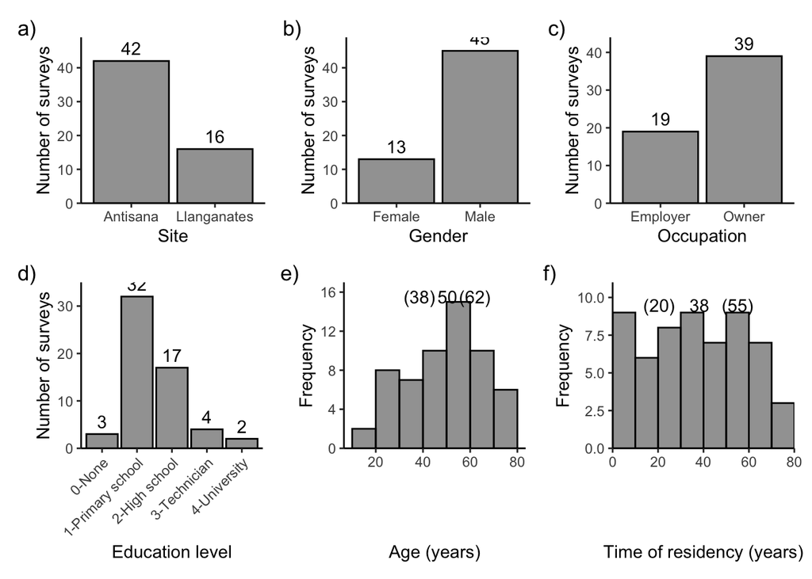

```r
FigSite <- perceptions |>
  mutate(Site = ifelse(`Paddock site` == 0, "Antisana", "Llanganates")) |>
  ggplot(aes(x = Site)) +
    geom_bar(alpha = 0.6, color = "black") +
    geom_text(aes(label = after_stat(count)), stat = "count", vjust = -0.5)+
  scale_y_continuous(expand = c(0,0),
                     limits = c(0,49))+
    theme_classic()+
    labs(y = "Number of surveys",
         tag = "a)")

FigGender <- perceptions |>
  mutate(Gender = ifelse(Gender == 0, "Male", "Female")) |>
  ggplot(aes(x = Gender)) +
    geom_bar(alpha = 0.6, color = "black") +
    geom_text(aes(label = after_stat(count)), stat = "count", vjust = -0.5)+
    scale_y_continuous(expand = c(0,0),
                     limits = c(0,49))+
    theme_classic()+
    labs(y = "Number of surveys",
         tag = "b)")

FigOcup <- perceptions |>
  mutate(Occupation = ifelse(Occupation == 0, "Employer", "Owner")) |>
  ggplot(aes(x = Occupation)) +
    geom_bar(alpha = 0.6, color = "black") +
    geom_text(aes(label = after_stat(count)), stat = "count", vjust = -0.5)+
    scale_y_continuous(expand = c(0,0),
                     limits = c(0,44))+
    theme_classic()+
    labs(y = "Number of surveys",
         tag = "c)")

FigAge <- perceptions |>
  ggplot(aes(x = Age)) +
    geom_histogram(boundary = 0, binwidth = 10,
                   alpha = 0.6, color = "black") +
    scale_y_continuous(expand = c(0,0),
                       limits = c(0,17))+
    annotate("text", x = mean(perceptions$Age), y = 15.5,
             label = paste0(round(mean(perceptions$Age))))+
    annotate("text", x = quantile(perceptions$Age, 0.25), y = 15.5,
             label = paste0("(",round(quantile(perceptions$Age, 0.25)),")"))+
    annotate("text", x = quantile(perceptions$Age, 0.75), y = 15.5,
             label = paste0("(",round(quantile(perceptions$Age, 0.75)),")"))+
    theme_classic()+
    labs(y = "Frequency",
         x = "Age (years)",
         tag ="e)")

FigResi <- perceptions |>
  ggplot(aes(x = `Time of residence`)) +
    geom_histogram(boundary = 0, binwidth = 10,
                   alpha = 0.6, color = "black") +
    scale_y_continuous(expand = c(0,0),
                       limits = c(0,11))+
    scale_x_continuous(expand = c(0,0))+
    annotate("text", x = mean(perceptions$`Time of residence`), y = 9.5,
             label = round(mean(perceptions$`Time of residence`)))+
    annotate("text", x = quantile(perceptions$`Time of residence`, 0.25), y = 9.5,
             label = paste0("(",round(quantile(perceptions$`Time of residence`, 0.25)),")"))+
    annotate("text", x = quantile(perceptions$`Time of residence`, 0.75), y = 9.5,
             label = paste0("(",round(quantile(perceptions$`Time of residence`, 0.75)),")"))+
    theme_classic()+
    labs(y = "Frequency",
         x = "Time of residency (years)",
         tag = "f)")

FigEdu <- perceptions |>
  mutate(`Education level` = ifelse(`Education level`== 0, "0-None",
                             ifelse(`Education level`==1, "1-Primary school",
                             ifelse(`Education level`==2,"2-High school",
                             ifelse(`Education level`==3, "3-Technician",
                             ifelse(`Education level`==4, "4-University",
                             NA)))))) |>
  ggplot(aes(x = `Education level`))+
    geom_bar(alpha = 0.6, color = "black") +
    geom_text(aes(label = after_stat(count)), stat = "count", vjust = -0.5)+
    scale_y_continuous(expand = c(0,0),
                     limits = c(0,35))+
    theme_classic()+
    labs(y = "Number of surveys",
         tag = "d)")+
    theme(axis.text.x = element_text(angle = 45, hjust = 1, vjust = 1))

(FigSite | FigGender | FigOcup) / (FigEdu | FigAge | FigResi)
```

```r
ggsave(filename = "figs/Fig_descriptive_geo_demo.jpg", dpi = 300,
       width = 260, height = 160, units = "mm")
```

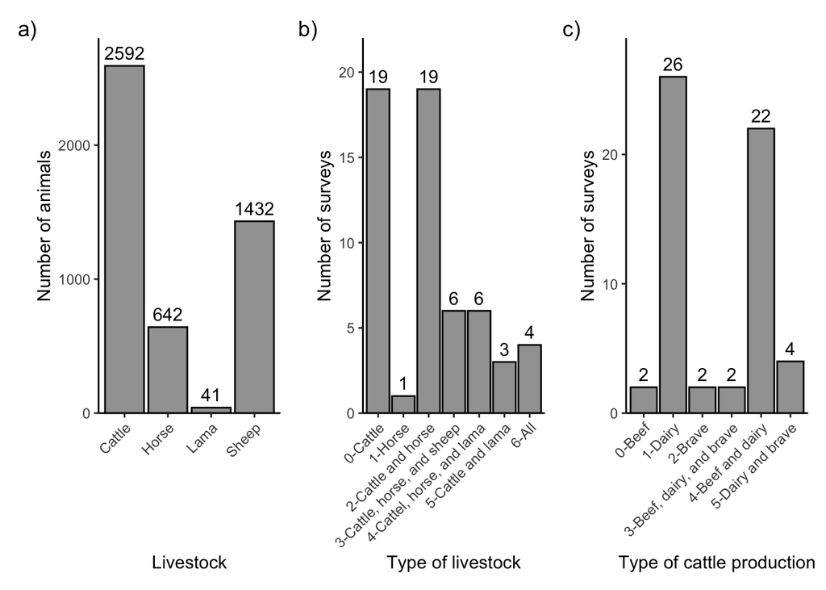

```r
FigNanimals <- perceptions |>
  dplyr::select(Subject, Cattle, Horse, Sheep, Lama) |>
  pivot_longer(cols = c(Cattle, Horse, Sheep, Lama),
               names_to = "Livestock", values_to = "Number of animals") |>
  group_by(Livestock) |>
  summarise(`Number of animals` = sum(`Number of animals`, na.rm = TRUE), .groups = "drop") |>
  ggplot(aes(x = Livestock, y = `Number of animals`)) +
    geom_col(alpha = 0.6, color = "black") +
    geom_text(aes(label = `Number of animals`), vjust = -0.5)+
    scale_y_continuous(expand = c(0,0),
                       limits = c(0,2800))+
    labs(y = "Number of animals",
         fill = "",
         tag = "a)")+
    theme_classic()+
  theme(axis.text.x = element_text(angle = 45, hjust = 1, vjust = 1))

FigTypeL <- perceptions |>
  mutate(`Type of livestock` = ifelse(`Type of livestock`== 0, "0-Cattle",
                                    ifelse(`Type of livestock`==1, "1-Horse",
                                           ifelse(`Type of livestock`==2,"2-Cattle and horse",
                                                  ifelse(`Type of livestock`==3, "3-Cattle, horse, and sheep",
                                                         ifelse(`Type of livestock`==4, "4-Cattel, horse, and lama",
                                                                ifelse(`Type of livestock`==5, "5-Cattle and lama",
                                                                       ifelse(`Type of livestock`==6, "6-All",
                                                                              NA)))))))) |>
  ggplot(aes(x = `Type of livestock`))+
    geom_bar(alpha = 0.6, color = "black") +
    geom_text(aes(label = after_stat(count)), stat = "count", vjust = -0.5)+
    scale_y_continuous(expand = c(0,0),
                     limits = c(0,22))+
    labs(y = "Number of surveys",
         tag = "b)")+
    theme_classic() +
    theme(axis.text.x = element_text(angle = 45, hjust = 1, vjust = 1))


FigTypeP <- perceptions |>
  mutate(`Type of cattle production` = ifelse(`Type of cattle production`== 0, "0-Beef",
                                    ifelse(`Type of cattle production`==1, "1-Dairy",
                                    ifelse(`Type of cattle production`==2,"2-Brave",
                                    ifelse(`Type of cattle production`==3, "3-Beef, dairy, and brave",
                                    ifelse(`Type of cattle production`==4, "4-Beef and dairy",
                                    ifelse(`Type of cattle production`==5, "5-Dairy and brave",
                                    NA))))))) |>
  ggplot(aes(x = `Type of cattle production`))+
    geom_bar(alpha = 0.6, color = "black") +
    geom_text(aes(label = after_stat(count)), stat = "count", vjust = -0.5)+
    scale_y_continuous(expand = c(0,0),
                     limits = c(0,29))+
    labs(y = "Number of surveys",
         tag = "c)")+
    theme_classic() +
    theme(axis.text.x = element_text(angle = 45, hjust = 1, vjust = 1))

(FigNanimals | FigTypeL | FigTypeP)
```

```r
ggsave(filename = "figs/Fig_descriptive_farm_livestock.jpg", dpi = 300,
       width = 260, height = 100, units = "mm")
```

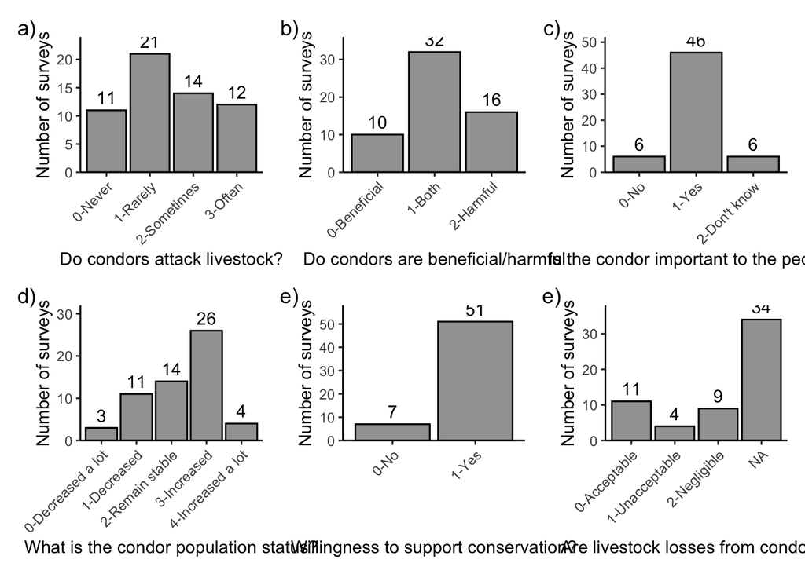

```r
FigPerception <- perceptions |>
  mutate(`Do condors attack livestock?` = ifelse(`Do you think condors attack living livestock?`== 0, "0-Never",
                                    ifelse(`Do you think condors attack living livestock?`==1, "1-Rarely",
                                    ifelse(`Do you think condors attack living livestock?`==2,"2-Sometimes",
                                    ifelse(`Do you think condors attack living livestock?`==3, "3-Often",NA))))) |>
  ggplot(aes(x = `Do condors attack livestock?`))+
    geom_bar(alpha = 0.6, color = "black") +
    geom_text(aes(label = after_stat(count)), stat = "count", vjust = -0.5)+
    scale_y_continuous(expand = c(0,0),
                     limits = c(0,24))+
    labs(y = "Number of surveys",
         tag = "a)")+
    theme_classic() +
    theme(axis.text.x = element_text(angle = 45, hjust = 1, vjust = 1))

FigBenef <- perceptions |>
  mutate(`Do condors are beneficial/harmful` = ifelse(`Could you indicate if the Andean condor is beneficial and/or harmful to you?`== 0, "2-Harmful",
                                    ifelse(`Could you indicate if the Andean condor is beneficial and/or harmful to you?`==1, "0-Beneficial",
                                    ifelse(`Could you indicate if the Andean condor is beneficial and/or harmful to you?`==2,"1-Both",NA)))) |>
  ggplot(aes(x = `Do condors are beneficial/harmful`))+
    geom_bar(alpha = 0.6, color = "black") +
    geom_text(aes(label = after_stat(count)), stat = "count", vjust = -0.5)+
    scale_y_continuous(expand = c(0,0),
                     limits = c(0,36))+
    labs(y = "Number of surveys",
         tag = "b)")+
    theme_classic() +
    theme(axis.text.x = element_text(angle = 45, hjust = 1, vjust = 1))

FigPercPop <- perceptions |>
  mutate(`What is the condor population status?` = ifelse(`Do you consider that the Andean condor population in this area?`== 0, "0-Decreased a lot",
                                    ifelse(`Do you consider that the Andean condor population in this area?`==1, "1-Decreased",
                                    ifelse(`Do you consider that the Andean condor population in this area?`==2,"2-Remain stable",
                                    ifelse(`Do you consider that the Andean condor population in this area?`==3, "3-Increased",
                                    ifelse(`Do you consider that the Andean condor population in this area?`==4, "4-Increased a lot", NA)))))) |>
  ggplot(aes(x = `What is the condor population status?`))+
    geom_bar(alpha = 0.6, color = "black") +
    geom_text(aes(label = after_stat(count)), stat = "count", vjust = -0.5)+
    scale_y_continuous(expand = c(0,0),
                     limits = c(0,32))+
    labs(y = "Number of surveys",
         tag = "d)")+
    theme_classic() +
    theme(axis.text.x = element_text(angle = 45, hjust = 1, vjust = 1))

FigImportance <- perceptions |>
  mutate(`Is the condor important to the people?` = ifelse(`Do you think the Andean condor is important to people?`== 0, "1-Yes",
                                    ifelse(`Do you think the Andean condor is important to people?`== 1, "0-No",
                                    ifelse(`Do you think the Andean condor is important to people?`== 2,"2-Don't know",NA)))) |>
  ggplot(aes(x = `Is the condor important to the people?`))+
    geom_bar(alpha = 0.6, color = "black") +
    geom_text(aes(label = after_stat(count)), stat = "count", vjust = -0.5)+
    scale_y_continuous(expand = c(0,0),
                     limits = c(0,52))+
    labs(y = "Number of surveys",
         tag = "c)")+
    theme_classic() +
    theme(axis.text.x = element_text(angle = 45, hjust = 1, vjust = 1))

FigConserv <- perceptions |>
  mutate(`Willingness to support conservation?` = ifelse(`Would you be willing to support the protection of the Andean condor on your farm?`== 0, "1-Yes",
                                    ifelse(`Would you be willing to support the protection of the Andean condor on your farm?`== 1, "0-No",NA))) |>
  ggplot(aes(x = `Willingness to support conservation?`))+
    geom_bar(alpha = 0.6, color = "black") +
    geom_text(aes(label = after_stat(count)), stat = "count", vjust = -0.5)+
    scale_y_continuous(expand = c(0,0),
                     limits = c(0,58))+
    labs(y = "Number of surveys",
         tag = "e)")+
    theme_classic() +
    theme(axis.text.x = element_text(angle = 45, hjust = 1, vjust = 1))

FigAcceptance <- perceptions |>
  mutate(`Are livestock losses from condors?` = ifelse(`If you have suffered the loss of livestock due to attacks by condors in the last 5 years, do you consider these losses acceptable, unacceptable, or negligible?`== 0, "0-Acceptable",
                                    ifelse(`If you have suffered the loss of livestock due to attacks by condors in the last 5 years, do you consider these losses acceptable, unacceptable, or negligible?`== 1, "2-Negligible",
                                    ifelse(`If you have suffered the loss of livestock due to attacks by condors in the last 5 years, do you consider these losses acceptable, unacceptable, or negligible?`== 2,"1-Unacceptable",NA)))) |>
  ggplot(aes(x = `Are livestock losses from condors?`))+
    geom_bar(alpha = 0.6, color = "black") +
    geom_text(aes(label = after_stat(count)), stat = "count", vjust = -0.5)+
    scale_y_continuous(expand = c(0,0),
                     limits = c(0,38))+
    labs(y = "Number of surveys",
         tag = "e)")+
    theme_classic() +
    theme(axis.text.x = element_text(angle = 45, hjust = 1, vjust = 1))

(FigPerception | FigBenef | FigImportance) / (FigPercPop | FigConserv | FigAcceptance)
```

```r
ggsave(filename = "figs/Fig_descriptive_perceptions.jpg", dpi = 300,
       width = 260, height = 160, units = "mm")
```

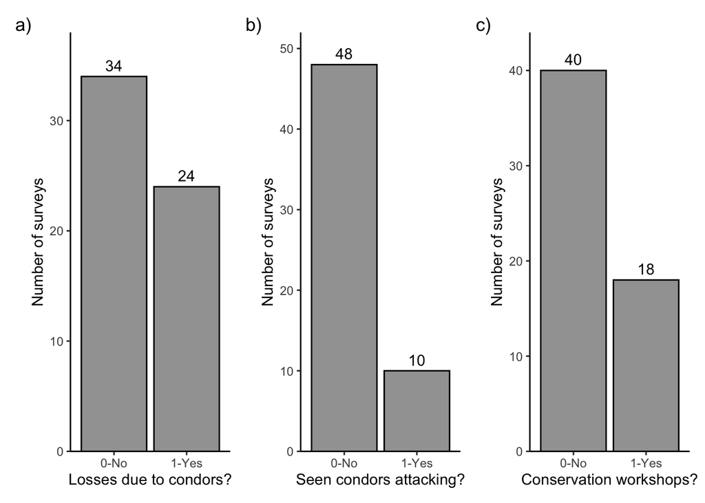

```r
FigLosses <- perceptions |>
  mutate(`Losses due to condors?` = ifelse(`Have you suffered losses of livestock due to attacks by condors?` == 0, "1-Yes",
                                                        ifelse(`Have you suffered losses of livestock due to attacks by condors?` == 1, "0-No",NA))) |>
  ggplot(aes(x = `Losses due to condors?`)) +
    geom_bar(alpha = 0.6, color = "black") +
    geom_text(aes(label = after_stat(count)), stat = "count", vjust = -0.5)+
    scale_y_continuous(expand = c(0,0),
                       limits = c(0,38))+
    labs(y = "Number of surveys",
         fill = "",
         tag = "a)")+
    theme_classic()

FigSeenAttack <- perceptions |>
  mutate(`Seen condors attacking?` = ifelse(`Have you ever seen condors attacking living livestock?`== 0, "1-Yes",
                               ifelse(`Have you ever seen condors attacking living livestock?`== 1, "0-No",
                                      NA))) |>
  ggplot(aes(x = `Seen condors attacking?`))+
    geom_bar(alpha = 0.6, color = "black") +
    geom_text(aes(label = after_stat(count)), stat = "count", vjust = -0.5)+
    scale_y_continuous(expand = c(0,0),
                     limits = c(0,52))+
    labs(y = "Number of surveys",
         tag = "b)")+
    theme_classic()

FigWorkshops <- perceptions |>
  mutate(`Conservation workshops?` = ifelse(`Have you attended talks/trainings on the environment?`== 0, "1-Yes",
                                    ifelse(`Have you attended talks/trainings on the environment?`==1, "0-No",NA))) |>
  ggplot(aes(x = `Conservation workshops?`))+
    geom_bar(alpha = 0.6, color = "black") +
    geom_text(aes(label = after_stat(count)), stat = "count", vjust = -0.5)+
    scale_y_continuous(expand = c(0,0),
                     limits = c(0,44))+
    labs(y = "Number of surveys",
         tag = "c)")+
    theme_classic()

(FigLosses | FigSeenAttack | FigWorkshops)
```

```r
ggsave(filename = "figs/Fig_descriptive_farm_experiences.jpg", dpi = 300,
       width = 260, height = 100, units = "mm")
```

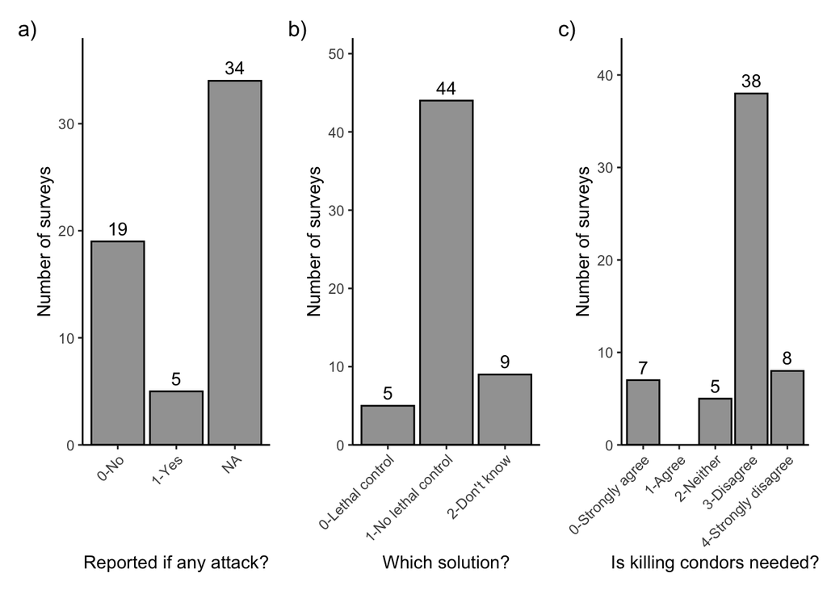

```r
FigReport <- perceptions |>
  mutate(`Reported if any attack?` = ifelse(`If you have suffered an attack in the last 5 years, have you reported it to the provincial authority?` == 0, "1-Yes",
                                                        ifelse(`If you have suffered an attack in the last 5 years, have you reported it to the provincial authority?` == 1, "0-No",NA))) |>
  ggplot(aes(x = `Reported if any attack?`)) +
    geom_bar(alpha = 0.6, color = "black") +
    geom_text(aes(label = after_stat(count)), stat = "count", vjust = -0.5)+
    scale_y_continuous(expand = c(0,0),
                       limits = c(0,38))+
    labs(y = "Number of surveys",
         fill = "",
         tag = "a)")+
    theme_classic() +
    theme(axis.text.x = element_text(angle = 45, hjust = 1, vjust = 1))

FigLethal <- perceptions |>
  mutate(`Which solution?` = ifelse(`What do you think could be a solution to prevent Andean condors from attacking livestock?`== 0, "0-Lethal control",
                               ifelse(`What do you think could be a solution to prevent Andean condors from attacking livestock?`== 1, "1-No lethal control",
                               ifelse(`What do you think could be a solution to prevent Andean condors from attacking livestock?`== 2, "2-Don't know", NA)))) |>
  ggplot(aes(x = `Which solution?`))+
    geom_bar(alpha = 0.6, color = "black") +
    geom_text(aes(label = after_stat(count)), stat = "count", vjust = -0.5)+
    scale_y_continuous(expand = c(0,0),
                     limits = c(0,52))+
    labs(y = "Number of surveys",
         tag = "b)")+
    theme_classic() +
    theme(axis.text.x = element_text(angle = 45, hjust = 1, vjust = 1))

FigKilling <- perceptions |>
  mutate(`Is killing condors needed?` = factor(ifelse(`Killing condors is necessary to prevent further damage?`== 0, "0-Strongly agree",
                                    ifelse(`Killing condors is necessary to prevent further damage?`== 1, "1-Agree",
                                    ifelse(`Killing condors is necessary to prevent further damage?`== 2, "2-Neither",
                                    ifelse(`Killing condors is necessary to prevent further damage?`== 3, "3-Disagree",
                                    ifelse(`Killing condors is necessary to prevent further damage?`== 4, "4-Strongly disagree", NA))))),
         levels = c("0-Strongly agree",
                    "1-Agree",
                    "2-Neither",
                    "3-Disagree",
                    "4-Strongly disagree"),
         labels = c("0-Strongly agree",
                    "1-Agree",
                    "2-Neither",
                    "3-Disagree",
                    "4-Strongly disagree"))) |>
  ggplot(aes(x = `Is killing condors needed?`))+
    geom_bar(alpha = 0.6, color = "black") +
    geom_text(aes(label = after_stat(count)), stat = "count", vjust = -0.5)+
    scale_y_continuous(expand = c(0,0),
                     limits = c(0,44))+
  scale_x_discrete(drop = FALSE)+
    labs(y = "Number of surveys",
         tag = "c)")+
    theme_classic()+
    theme(axis.text.x = element_text(angle = 45, hjust = 1, vjust = 1))

(FigReport | FigLethal | FigKilling)
```

```r
ggsave(filename = "figs/Fig_descriptive_solutions.jpg", dpi = 300,
       width = 260, height = 100, units = "mm")
```

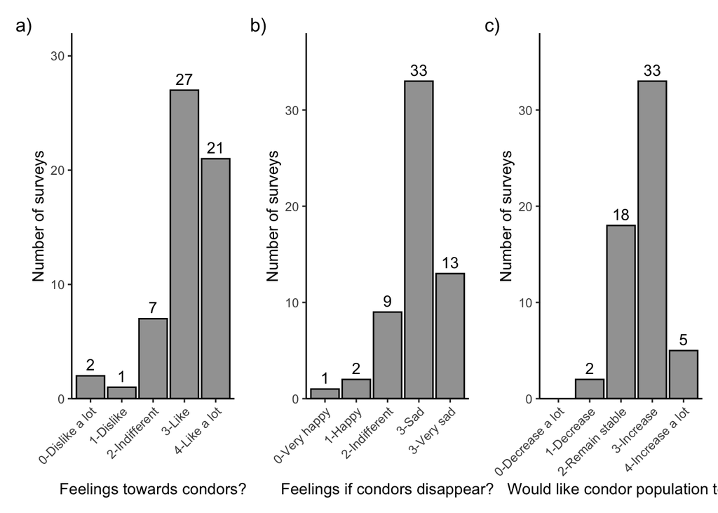

```r
FigFeelings <- perceptions |>
  mutate(`Feelings towards condors?` = ifelse(`What are your feelings towards Andean condors?` == 0, "4-Like a lot",
                                                        ifelse(`What are your feelings towards Andean condors?` == 1, "3-Like",
                                                        ifelse(`What are your feelings towards Andean condors?` == 2, "2-Indifferent",
                                                        ifelse(`What are your feelings towards Andean condors?` == 3, "1-Dislike",
                                                        ifelse(`What are your feelings towards Andean condors?` == 4, "0-Dislike a lot",NA)))))) |>
  ggplot(aes(x = `Feelings towards condors?`)) +
    geom_bar(alpha = 0.6, color = "black") +
    geom_text(aes(label = after_stat(count)), stat = "count", vjust = -0.5)+
    scale_y_continuous(expand = c(0,0),
                       limits = c(0,32))+
    labs(y = "Number of surveys",
         fill = "",
         tag = "a)")+
    theme_classic() +
    theme(axis.text.x = element_text(angle = 45, hjust = 1, vjust = 1))

FigDisappear <- perceptions |>
  mutate(`Feelings if condors disappear?` = ifelse(`What would you feel if all of the condors disappeared forever from the region?`== 0, "0-Very happy",
                               ifelse(`What would you feel if all of the condors disappeared forever from the region?`== 1, "1-Happy",
                               ifelse(`What would you feel if all of the condors disappeared forever from the region?`== 2, "2-Indifferent",
                               ifelse(`What would you feel if all of the condors disappeared forever from the region?`== 3, "3-Sad",
                               ifelse(`What would you feel if all of the condors disappeared forever from the region?`== 4, "3-Very sad",NA)))))) |>
  ggplot(aes(x = `Feelings if condors disappear?`))+
    geom_bar(alpha = 0.6, color = "black") +
    geom_text(aes(label = after_stat(count)), stat = "count", vjust = -0.5)+
    scale_y_continuous(expand = c(0,0),
                     limits = c(0,38))+
    labs(y = "Number of surveys",
         tag = "b)")+
    theme_classic() +
    theme(axis.text.x = element_text(angle = 45, hjust = 1, vjust = 1))

FigAttPop <- perceptions |>
  mutate(`Would like condor population to?` = factor(ifelse(`Would you like the Andean condor population in the National Park and the surrounding area to?`== 0, "0-Decrease a lot",
                                    ifelse(`Would you like the Andean condor population in the National Park and the surrounding area to?`== 1, "1-Decrease",
                                    ifelse(`Would you like the Andean condor population in the National Park and the surrounding area to?`== 2, "2-Remain stable",
                                    ifelse(`Would you like the Andean condor population in the National Park and the surrounding area to?`== 3, "3-Increase",
                                    ifelse(`Would you like the Andean condor population in the National Park and the surrounding area to?`== 4, "4-Increase a lot", NA))))),
         levels = c("0-Decrease a lot",
                    "1-Decrease",
                    "2-Remain stable",
                    "3-Increase",
                    "4-Increase a lot"),
         labels = c("0-Decrease a lot",
                    "1-Decrease",
                    "2-Remain stable",
                    "3-Increase",
                    "4-Increase a lot"))) |>
  ggplot(aes(x = `Would like condor population to?`))+
    geom_bar(alpha = 0.6, color = "black") +
    geom_text(aes(label = after_stat(count)), stat = "count", vjust = -0.5)+
    scale_y_continuous(expand = c(0,0),
                     limits = c(0,38))+
  scale_x_discrete(drop = FALSE)+
    labs(y = "Number of surveys",
         tag = "c)")+
    theme_classic()+
    theme(axis.text.x = element_text(angle = 45, hjust = 1, vjust = 1))

(FigFeelings | FigDisappear | FigAttPop)
```

```r
ggsave(filename = "figs/Fig_descriptive_attitudes.jpg", dpi = 300,
       width = 260, height = 100, units = "mm")
```

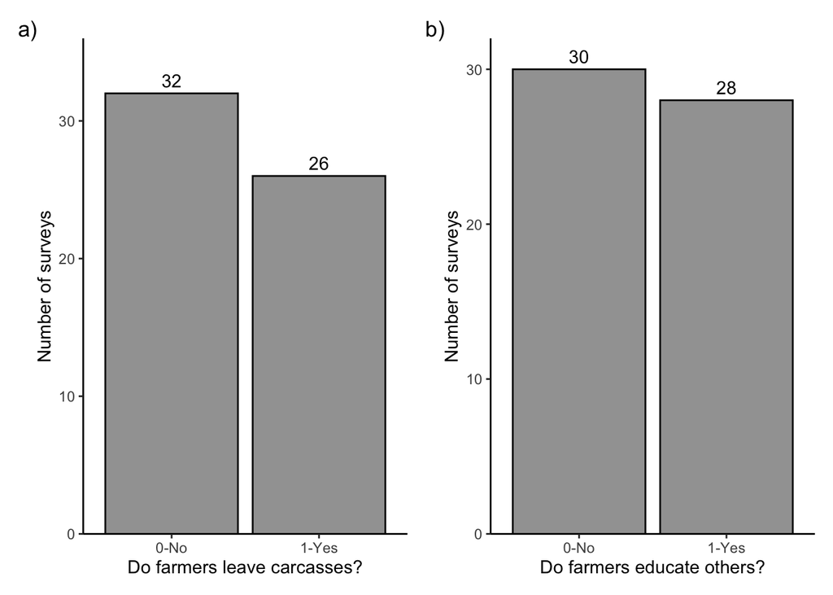

```r
FigLeave <- perceptions |>
  mutate(`Do farmers leave carcasses?` = ifelse(`Do you leave livestock carcasses in the field to be consumed by condors?`== 0, "1-Yes",
                                    ifelse(`Do you leave livestock carcasses in the field to be consumed by condors?`==1, "0-No",NA))) |>
  ggplot(aes(x = `Do farmers leave carcasses?`))+
    geom_bar(alpha = 0.6, color = "black") +
    geom_text(aes(label = after_stat(count)), stat = "count", vjust = -0.5)+
    scale_y_continuous(expand = c(0,0),
                     limits = c(0,36))+
    labs(y = "Number of surveys",
         tag = "a)")+
    theme_classic()

FigEduca <- perceptions |>
  mutate(`Do farmers educate others?` = ifelse(`Do you educate others about the importance of Andean condor conservation?`== 0, "1-Yes",
                                    ifelse(`Do you educate others about the importance of Andean condor conservation?`==1, "0-No",NA))) |>
  ggplot(aes(x = `Do farmers educate others?`))+
    geom_bar(alpha = 0.6, color = "black") +
    geom_text(aes(label = after_stat(count)), stat = "count", vjust = -0.5)+
    scale_y_continuous(expand = c(0,0),
                     limits = c(0,32))+
    labs(y = "Number of surveys",
         tag = "b)")+
    theme_classic()

(FigLeave | FigEduca)
```

```r
ggsave(filename = "figs/Fig_descriptive_behavior.jpg", dpi = 300,
       width = 160, height = 100, units = "mm")
```

Figure for results

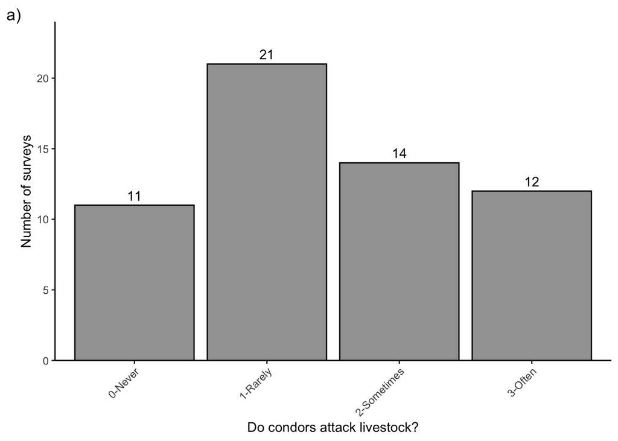

```r
FigPerception
```

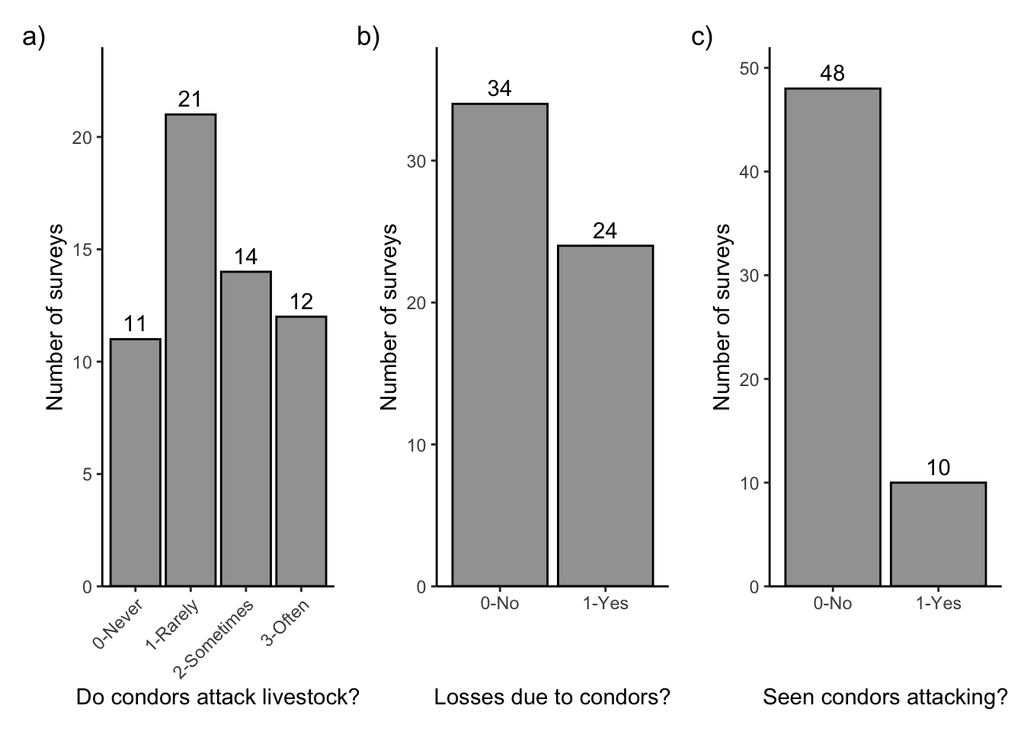

```r
FigLosses <- FigLosses +
  labs(tag = "b)")

FigSeenAttack <- FigSeenAttack +
  labs(tag = "c)")

FigPerception | FigLosses | FigSeenAttack
```

```r
ggsave(filename = "figs/Figure_1.jpg", dpi = 300,
       width = 180, height = 100, units = "mm")
```

# 3 Perception of people that Andean condor attacks livestock (aim 1)

Farmers perceive the Andean condor as a livestock predator, but vary with socio-demographic, farm characteristics, and experience/attitudes

## 3.1 Perception of attack predicted by socio-demographic (1a)

This is an ordinal variable (gradually ascending from Never to Often)

```r
perceptions_Y1 <- perceptions |>
  mutate(perceptions_1 = ordered(`Do you think condors attack living livestock?`,
                          levels = c(0, 1, 2, 3)),
         site = as.factor(ifelse(`Paddock site` == 0, "Antisana",
                       "Llanganates")),
         gender = as.factor(ifelse(Gender == 0, "Male", "Female")),
         age = Age,
         edu.level = factor(`Education level`,
                       levels = 0:4,
                       labels = c("0-None","1-Prim","2-High","3-Tech","4-Univ")),
         t.residence = `Time of residence`,
         occupation = as.factor(ifelse(Occupation == 0, "Employer","Owner")))

# sequencial contrast for education level
contrasts(perceptions_Y1$edu.level) <- MASS::contr.sdif(5)

# a list of ordered logistic regression
mods_perceptions_demogra <- list(
  site  = polr(perceptions_1 ~ site,  data = perceptions_Y1),
  gender  = polr(perceptions_1 ~ gender,  data = perceptions_Y1),
  age   = polr(perceptions_1 ~ age,  data = perceptions_Y1),
  edu.level  = polr(perceptions_1 ~ edu.level,  data = perceptions_Y1),
  t.residence  = polr(perceptions_1 ~ t.residence,  data = perceptions_Y1),
  occupation   = polr(perceptions_1 ~ occupation,  data = perceptions_Y1)
  )

AICcmodavg::aictab(mods_perceptions_demogra) # edu.level and t.residence
```

```
##
## Model selection based on AICc:
##
##             K   AICc Delta_AICc AICcWt Cum.Wt     LL
## edu.level   7 162.11       0.00   0.34   0.34 -73.81
## t.residence 4 163.04       0.92   0.21   0.55 -77.43
## age         4 164.16       2.04   0.12   0.67 -77.99
## gender      4 164.23       2.12   0.12   0.79 -78.03
## site        4 164.30       2.19   0.11   0.91 -78.06
## occupation  4 164.68       2.57   0.09   1.00 -78.25
```

```r
mods_perceptions_demogra <- list(
  null = polr(perceptions_1 ~ 1,
              data = perceptions_Y1, Hess = TRUE),
  site  = polr(perceptions_1 ~ site,
               data = perceptions_Y1, Hess = TRUE),
  gender  = polr(perceptions_1 ~ gender,
                 data = perceptions_Y1, Hess = TRUE),
  age   = polr(perceptions_1 ~ age,
               data = perceptions_Y1, Hess = TRUE),
  edu.level  = polr(perceptions_1 ~ edu.level,
                    data = perceptions_Y1, Hess = TRUE),
  t.residence  = polr(perceptions_1 ~ t.residence,
                      data = perceptions_Y1, Hess = TRUE),
  occupation   = polr(perceptions_1 ~ occupation,
                      data = perceptions_Y1, Hess = TRUE),
  # after first single model with deltaAIC < 2 for two models: edu.level and t.residence
  edu.t.res = polr(perceptions_1 ~ edu.level + t.residence,
                   data = perceptions_Y1, Hess = TRUE),
  global = polr(perceptions_1 ~ edu.level + t.residence + age + gender + site + occupation,
                   data = perceptions_Y1, Hess = TRUE)
)

AICcmodavg::aictab(mods_perceptions_demogra) # edu.level and t.residence
```

```
##
## Model selection based on AICc:
##
##              K   AICc Delta_AICc AICcWt Cum.Wt     LL
## edu.t.res    8 159.08       0.00   0.55   0.55 -71.22
## edu.level    7 162.11       3.03   0.12   0.67 -73.81
## null         3 162.96       3.88   0.08   0.74 -78.43
## t.residence  4 163.04       3.96   0.08   0.82 -77.43
## age          4 164.16       5.08   0.04   0.86 -77.99
## gender       4 164.23       5.15   0.04   0.90 -78.03
## site         4 164.30       5.22   0.04   0.94 -78.06
## occupation   4 164.68       5.60   0.03   0.98 -78.25
## global      12 165.51       6.43   0.02   1.00 -70.04
```

Getting the p-value for the predictors in the model

```r
ctbl_m1 <- coef(summary(mods_perceptions_demogra$edu.t.res))
pvals_m1 <- pnorm(abs(ctbl_m1[, "t value"]), lower.tail = FALSE) * 2
ctbl_m1 <- cbind(ctbl_m1, "p value" = pvals_m1)
ctbl_m1
```

```
##                    Value Std. Error    t value      p value
## edu.level2-1  1.77434059 1.29960650  1.3652906 0.1721617198
## edu.level3-2  1.64734710 0.61569479  2.6755905 0.0074597740
## edu.level4-3 -0.22050457 0.94256705 -0.2339405 0.8150312041
## edu.level5-4  0.38299004 1.61871546  0.2366012 0.8129661816
## t.residence   0.02799717 0.01260907  2.2203988 0.0263917097
## 0|1          -0.71975132 0.65026724 -1.1068547 0.2683567686
## 1|2           1.22407964 0.66748716  1.8338624 0.0666744157
## 2|3           2.56239452 0.71014272  3.6082811 0.0003082325
```

This identify that passing from primary to high school (second contrast, p = 0.0074) and Time of residence (p = 0.026) are the most significant predictors.

```r
exp(coef(mods_perceptions_demogra$edu.t.res)[2]) # estimated coefficient for Education level - Primary to High school
```

```
## edu.level3-2
##     5.193185
```

```r
exp(coef(mods_perceptions_demogra$edu.t.res)[5]) # estimated coefficient for Time of residence
```

```
## t.residence
##    1.028393
```

Moving from Primary to High school education increases by 5 times the odds of perceiving condors as harmful. Each additional year of residence increases the odds of perceiving condors as harmful by about 2.8%.

We can extract the coefficients and the variance-covariance to simulate probabilities with new data for the two variables

```r
nsim = 1000

# extract coefficients and vcov
coefs.ed.tr <- c(coef(mods_perceptions_demogra$edu.t.res), # slope
                 mods_perceptions_demogra$edu.t.res$zeta) # thresholds
vc.ed.tr <- vcov(mods_perceptions_demogra$edu.t.res)
vc.safe <- as.matrix(Matrix::nearPD(vc.ed.tr)$mat)

# simulate parameter sets
sim_coefs <- mvrnorm(nsim, mu = coefs.ed.tr, Sigma = vc.safe)
```

Generate new data for education level and median time of residence

```r
newdat_ed <- expand.grid(
  edu.level = levels(perceptions_Y1$edu.level),
  t.residence = median(perceptions_Y1$t.residence)
)
```

And new data for timer of residence range, including the levels of education level

```r
newdat_tr <- expand.grid(
  edu.level = levels(perceptions_Y1$edu.level),
  t.residence = seq(min(perceptions_Y1$t.residence),
                    max(perceptions_Y1$t.residence),
                    length = 100)
)
```

And predict probabilities for each simulation

```r
pred_list_ed <- lapply(1:nsim, function(i) {
  predict_from_params(sim_coefs[i,], newdat_ed, mods_perceptions_demogra$edu.t.res)
})

pred_array_ed <- simplify2array(pred_list_ed)
# dim: [ row, category, simulation ] = 5 (as in newdat_ed) x 4 ordinal outcomes (Never, Rarely, Sometimes, Often) x 1000 simulations

# summarizing and CI across simualtions
med_ed <- apply(pred_array_ed, c(1, 2), median)
low_ed <- apply(pred_array_ed, c(1, 2), quantile, 0.025)
upp_ed <- apply(pred_array_ed, c(1, 2), quantile, 0.975)

# dim: [ row, category ] = 5 x 4

colnames(med_ed) <- c(paste("med_ed",colnames(med_ed)))
colnames(low_ed) <- c(paste("low_ed",colnames(low_ed)))
colnames(upp_ed) <- c(paste("upp_ed",colnames(upp_ed)))

pred_ed <- cbind(newdat_ed, med_ed, low_ed, upp_ed)

# convert to long format
pred_ed_long <- pred_ed |>
  pivot_longer(
    cols = starts_with(c("med_ed", "low_ed", "upp_ed")),
    names_to = c("stat", "cat"),
    names_pattern = "(med_ed|low_ed|upp_ed) (\\d)",
    values_to = "value"
  ) |>
  mutate(Category = recode(cat,
                      "0" = "Never",
                      "1" = "Rarely",
                      "2" = "Sometimes",
                      "3" = "Often"),
         Category = factor(Category,
                              levels = c("Never",
                                         "Rarely",
                                         "Sometimes",
                                         "Often"))) |>
  dplyr::select(-cat) |>
  pivot_wider(
    names_from = stat,
    values_from = value,
    names_prefix = ""
  ) |>
  rename(
    median = `med_ed`,
    lower  = `low_ed`,
    upper  = `upp_ed`
  )

# Time of residency

pred_list_tr <- lapply(1:nsim, function(i) {
  predict_from_params(sim_coefs[i,], newdat_tr, mods_perceptions_demogra$edu.t.res)
})

pred_array_tr <- simplify2array(pred_list_tr)
# dim: [ row, category, simulation ] = 500 (as in newdat_tr) x 4 ordinal outcomes (Never, Rarely, Sometimes, Often) x 1000 simulations

# summarizing and CI across simualtions
med_tr <- apply(pred_array_tr, c(1, 2), median)
low_tr <- apply(pred_array_tr, c(1, 2), quantile, 0.025)
upp_tr <- apply(pred_array_tr, c(1, 2), quantile, 0.975)

# dim: [ row, category ] = 500 x 4

colnames(med_tr) <- c(paste("med_tr",colnames(med_tr)))
colnames(low_tr) <- c(paste("low_tr",colnames(low_tr)))
colnames(upp_tr) <- c(paste("upp_tr",colnames(upp_tr)))

pred_tr <- cbind(newdat_tr, med_tr, low_tr, upp_tr)

# convert to long format
pred_tr_long <- pred_tr |>
  pivot_longer(
    cols = starts_with(c("med_tr", "low_tr", "upp_tr")),
    names_to = c("stat", "cat"),
    names_pattern = "(med_tr|low_tr|upp_tr) (\\d)",
    values_to = "value"
  ) |>
  mutate(Category = recode(cat,
                      "0" = "Never",
                      "1" = "Rarely",
                      "2" = "Sometimes",
                      "3" = "Often"),
         Category = factor(Category,
                              levels = c("Never",
                                         "Rarely",
                                         "Sometimes",
                                         "Often"))) |>
  dplyr::select(-cat) |>
  pivot_wider(
    names_from = stat,
    values_from = value,
    names_prefix = ""
  ) |>
  rename(
    median = `med_tr`,
    lower  = `low_tr`,
    upper  = `upp_tr`
  )
```

And make the figures

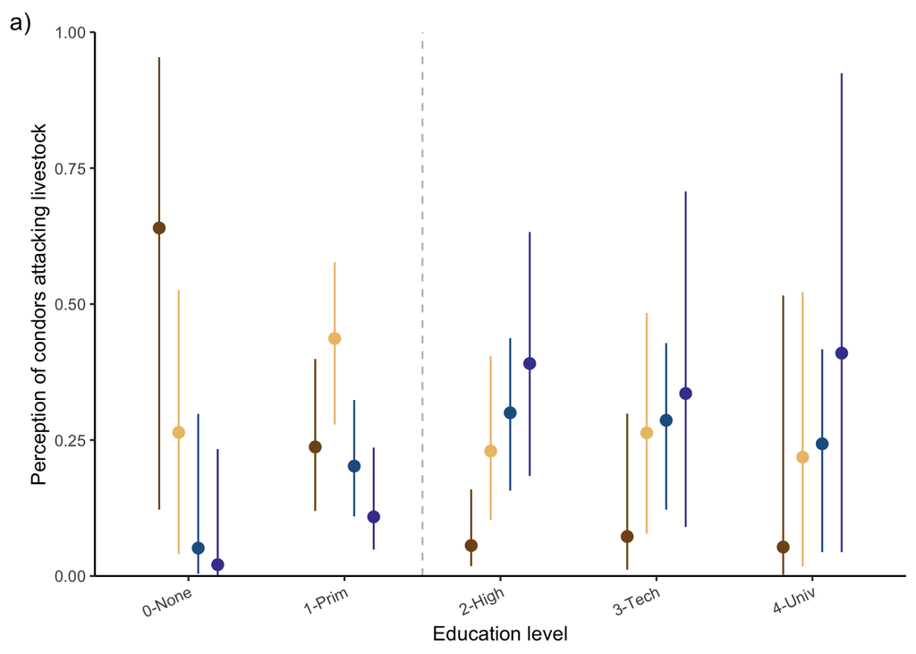

```r
p_ed_ci <- ggplot(pred_ed_long, aes(x = edu.level,
                         y = median,
                         color = Category)) +
  geom_pointrange(aes(ymin = lower, ymax = upper), position = position_dodge(width = 0.5))+
  geom_vline(xintercept = 2.5, linetype = "dashed", color = "gray")+
  scale_y_continuous(expand = c(0,0),
                     limits = c(0,1))+
  scale_color_manual(values = met.brewer("Manet",4))+
  labs(x = "Education level",
       y = "Perception of condors attacking livestock",
       tag = "a)")+
  theme_classic()+
  theme(legend.position = "none",
        axis.text.x = element_text(angle = 25, hjust = 1, vjust = 1))
p_ed_ci
```

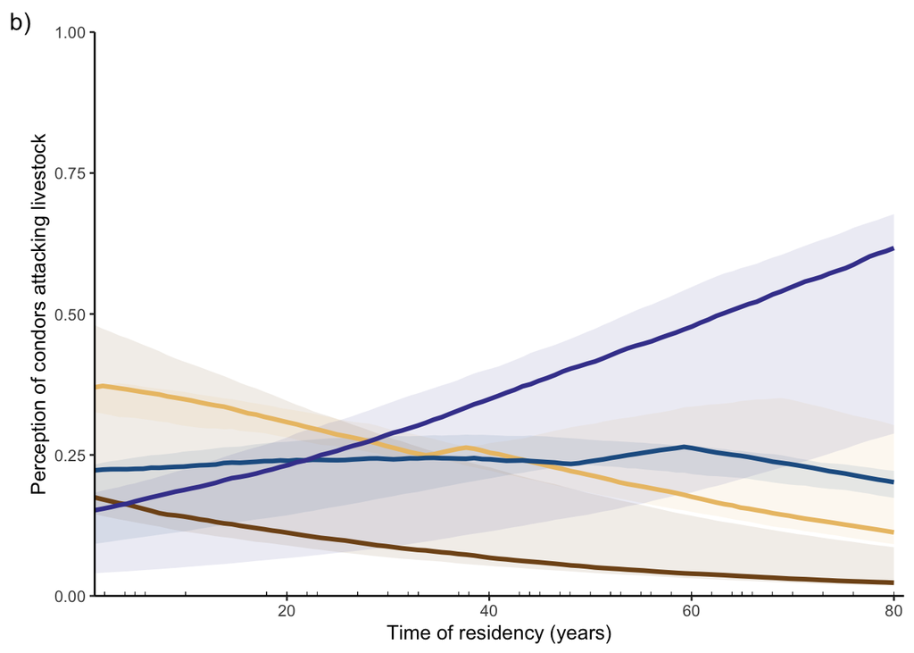

```r
p_tr_ci <- ggplot(pred_tr_long,
                  aes(x = t.residence,
                      y = median)) +
  stat_summary(fun.data = function(z) data.frame(
    y = median(z),
    ymin = quantile(z, 0.25),
    ymax = quantile(z, 0.75)
  ), geom = "ribbon", alpha = 0.1, color = NA, aes(fill = Category)) +
  stat_summary(fun = median, geom = "line", size = 1.2, aes(color = Category)) +
  geom_point(data = perceptions_Y1, aes(x = t.residence, y = 0), shape = "|", fill = "black")+
  scale_y_continuous(expand = c(0,0),
                     limits = c(0,1))+
  scale_x_continuous(expand = c(0,0),
                     limits = c(1, 81))+
  scale_fill_manual(values = met.brewer("Manet",4))+
  scale_color_manual(values = met.brewer("Manet",4))+
  labs(x = "Time of residency (years)",
       y = "Perception of condors attacking livestock",
       tag = "b)")+
  theme_classic()+
  theme(legend.position = "none")
p_tr_ci
```

Combine the figures

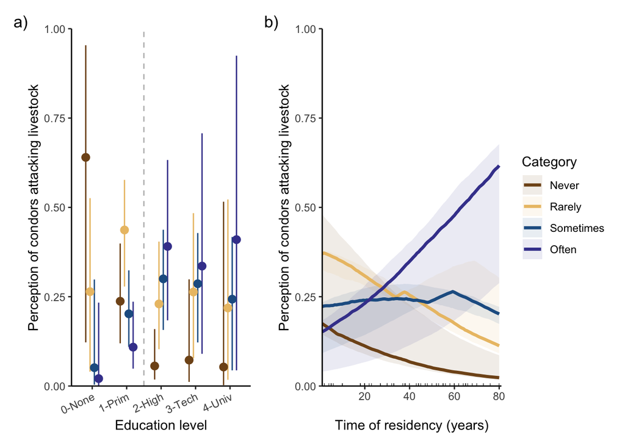

```r
(p_ed_ci | p_tr_ci) +
  plot_layout(guides = "collect") +
  theme(
    legend.position = "bottom",
    legend.direction = "vertical"
  )
```

[figure not shown]

```r
ggsave(filename = "figs/Fig_Aim1_a_perception.jpg", dpi = 300,
       width = 260, height = 100, units = "mm")
```

## 3.2 Perception of attack predicted by farm characteristics (1b)

Same ordinal variable (gradually ascending from Never to Often)

```r
perceptions_Y2 <- perceptions |>
  mutate(perceptions_1 = ordered(`Do you think condors attack living livestock?`,
                          levels = c(0, 1, 2, 3)),
         t.livestock = ifelse(`Type of livestock`== 0, "0-Cattle",
                       ifelse(`Type of livestock`==1, "1-Horse",
                       ifelse(`Type of livestock`==2,"2-Cattle and horse",
                       ifelse(`Type of livestock`==3, "3-Cattle, horse, and sheep",
                       ifelse(`Type of livestock`==4, "4-Cattel, horse, and lama",
                       ifelse(`Type of livestock`==5, "5-Cattle and lama",
                       ifelse(`Type of livestock`==6, "6-All",
                       NA))))))),
         n.cattle = ifelse(is.na(Cattle), 0, Cattle),
         n.horses = ifelse(is.na(Horse), 0, Horse),
         n.sheep = ifelse(is.na(Sheep), 0, Sheep),
         n.lama = ifelse(is.na(Lama), 0, Lama),
         t.production = ifelse(`Type of cattle production`== 0, "0-Beef",
                                    ifelse(`Type of cattle production`==1, "1-Dairy",
                                    ifelse(`Type of cattle production`==2,"2-Brave",
                                    ifelse(`Type of cattle production`==3, "3-Beef, dairy, and brave",
                                    ifelse(`Type of cattle production`==4, "4-Beef and dairy",
                                    ifelse(`Type of cattle production`==5, "5-Dairy and brave",
                                    NA)))))))

# a list of ordered logistic regression
mods_perceptions_farm <- list(
  null = polr(perceptions_1 ~ 1, data = perceptions_Y2, Hess = TRUE),
  t.livestock  = polr(perceptions_1 ~ t.livestock,  data = perceptions_Y2, Hess = TRUE),
  n.cattle  = polr(perceptions_1 ~ n.cattle,  data = perceptions_Y2, Hess = TRUE),
  n.horses   = polr(perceptions_1 ~ n.horses,  data = perceptions_Y2, Hess = TRUE),
  n.sheep  = polr(perceptions_1 ~ n.sheep,  data = perceptions_Y2, Hess = TRUE),
  n.lama  = polr(perceptions_1 ~ n.lama,  data = perceptions_Y2, Hess = TRUE),
  # as farmers include combination of livestock, we can include these additive potential effects
  n.cattle.horse = polr(perceptions_1 ~ n.cattle + n.horses,  data = perceptions_Y2, Hess = TRUE),
  n.cattle.lama = polr(perceptions_1 ~ n.cattle + n.lama,  data = perceptions_Y2, Hess = TRUE),
  t.production   = polr(perceptions_1 ~ t.production,  data = perceptions_Y2, Hess = TRUE),
  global = polr(perceptions_1 ~ t.livestock + n.cattle + n.horses + n.lama + n.sheep + t.production,  data = perceptions_Y2, Hess = TRUE),
  global.2 = polr(perceptions_1 ~ n.cattle + n.horses + n.lama + n.sheep + t.production,  data = perceptions_Y2, Hess = TRUE)
  )
AICcmodavg::aictab(mods_perceptions_farm) # all but t.livestock... cattle?
```

```
##
## Model selection based on AICc:
##
##                 K   AICc Delta_AICc AICcWt Cum.Wt     LL
## n.horses        4 162.30       0.00   0.20   0.20 -77.06
## n.cattle        4 162.51       0.21   0.18   0.38 -77.17
## null            3 162.96       0.66   0.14   0.52 -78.43
## t.production    8 163.43       1.13   0.11   0.63 -73.39
## n.sheep         4 163.44       1.14   0.11   0.74 -77.63
## n.cattle.lama   5 163.92       1.62   0.09   0.83 -76.83
## n.cattle.horse  5 164.20       1.89   0.08   0.91 -76.97
## n.lama          4 164.29       1.99   0.07   0.98 -78.06
## global.2       12 168.79       6.49   0.01   0.99 -71.68
## t.livestock     9 168.95       6.65   0.01   0.99 -75.07
## global         18 169.45       7.14   0.01   1.00 -65.12
```

Getting the p-value for the predictors in the model

```r
ctbl_m2 <- coef(summary(mods_perceptions_farm$n.cattle))
pvals_m2 <- pnorm(abs(ctbl_m2[, "t value"]), lower.tail = FALSE) * 2
ctbl_m2 <- cbind(ctbl_m2, "p value" = pvals_m2)
ctbl_m2
```

```
##                 Value  Std. Error   t value      p value
## n.cattle  0.005674117 0.003743088  1.515892 1.295466e-01
## 0|1      -1.243789633 0.359536433 -3.459426 5.413283e-04
## 1|2       0.446760539 0.307902867  1.450979 1.467858e-01
## 2|3       1.621801243 0.377797849  4.292775 1.764536e-05
```

```r
exp(coef(mods_perceptions_farm$n.cattle)[1]) # estimated coefficient for number of cattle
```

```
## n.cattle
##  1.00569
```

Plot the results with a new dataset for predictions

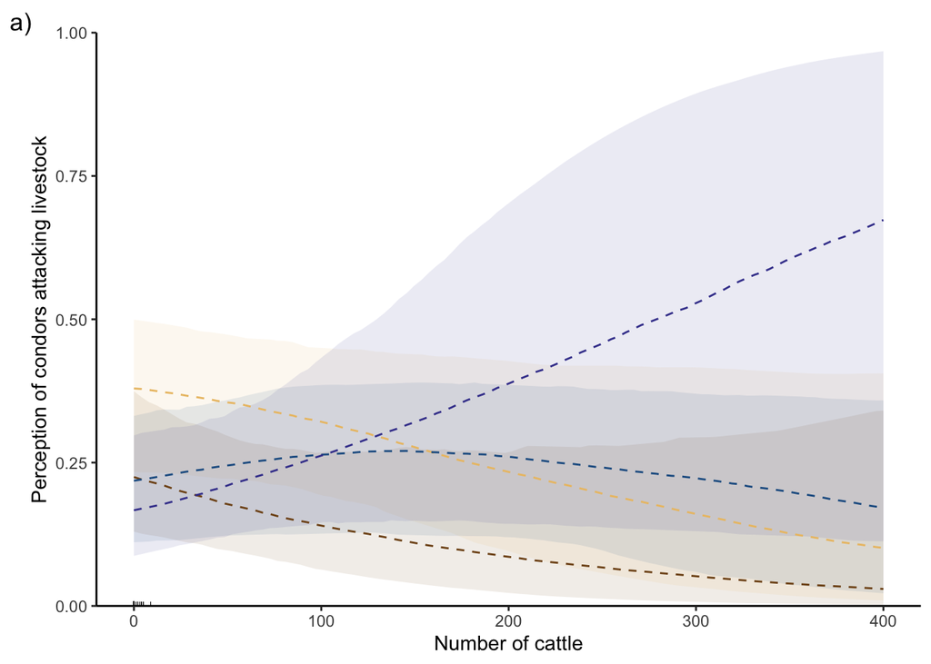

```r
newdat_m2 <- expand.grid(
  n.cattle = seq(min(perceptions_Y2$n.cattle, na.rm = TRUE),
                max(perceptions_Y2$n.cattle, na.rm = TRUE),
                length = 100)
)

# simulate data
nsim = 1000

# extract coefficients and vcov
coefs.m2 <- c(coef(mods_perceptions_farm$n.cattle), # slope
                 mods_perceptions_farm$n.cattle$zeta) # thresholds
vc.m2 <- vcov(mods_perceptions_farm$n.cattle)
vc.safe.m2 <- as.matrix(Matrix::nearPD(vc.m2)$mat)

# simulate parameter sets
sim_coefs.m2 <- mvrnorm(nsim, mu = coefs.m2, Sigma = vc.safe.m2)

# predict values from model
pred_list_m2 <- lapply(1:nsim, function(i) {
  predict_from_params(sim_coefs.m2[i,], newdat_m2, mods_perceptions_farm$n.cattle)
})

pred_array_m2 <- simplify2array(pred_list_m2)
# dim: [ row, category, simulation ] = 100 (as in newdat_m2) x 4 ordinal outcomes (Never, Rarely, Sometimes, Often) x 1000 simulations

# summarizing and CI across simualtions
med_m2 <- apply(pred_array_m2, c(1, 2), median)
low_m2 <- apply(pred_array_m2, c(1, 2), quantile, 0.025)
upp_m2 <- apply(pred_array_m2, c(1, 2), quantile, 0.975)

# dim: [ row, category ] = 100 x 4

colnames(med_m2) <- c(paste("med_m2",colnames(med_m2)))
colnames(low_m2) <- c(paste("low_m2",colnames(low_m2)))
colnames(upp_m2) <- c(paste("upp_m2",colnames(upp_m2)))

pred_m2 <- cbind(newdat_m2, med_m2, low_m2, upp_m2)

# convert to long format
pred_m2_long <- pred_m2 |>
  pivot_longer(
    cols = starts_with(c("med_m2", "low_m2", "upp_m2")),
    names_to = c("stat", "cat"),
    names_pattern = "(med_m2|low_m2|upp_m2) (\\d)",
    values_to = "value"
  ) |>
  mutate(Category = recode(cat,
                      "0" = "Never",
                      "1" = "Rarely",
                      "2" = "Sometimes",
                      "3" = "Often"),
         Category = factor(Category,
                              levels = c("Never",
                                         "Rarely",
                                         "Sometimes",
                                         "Often"))) |>
  dplyr::select(-cat) |>
  pivot_wider(
    names_from = stat,
    values_from = value,
    names_prefix = ""
  ) |>
  rename(
    median = `med_m2`,
    lower  = `low_m2`,
    upper  = `upp_m2`
  )

p_cattle <- ggplot(pred_m2_long, aes(x = n.cattle,
                         y = median)) +
  geom_ribbon(aes(ymin = lower, ymax = upper, fill = Category), color = NA, alpha = 0.1) +
  geom_line(aes(color = Category), linetype = "dashed") +
  geom_point(data = perceptions_Y2, aes(x = n.lama, y = 0), shape = "|", color = "black")+
  scale_y_continuous(expand = c(0,0),
                     limits = c(0,1))+
  scale_fill_manual(values = met.brewer("Manet",4))+
  scale_color_manual(values = met.brewer("Manet",4))+
  labs(x = "Number of cattle",
       y = "Perception of condors attacking livestock",
       tag = "a)")+
  theme_classic() +
  theme(legend.position = "none")
p_cattle
```

We can combine this figure with the next sub aim

## 3.3 Perception of attack predicted by experiences/attitudes (1c)

Same ordinal variable (gradually ascending from Never to Often)

```r
perceptions_Y3 <- perceptions |>
  mutate(perceptions_1 = ordered(`Do you think condors attack living livestock?`,
                          levels = c(0, 1, 2, 3)),
         seen.attack = ifelse(`Have you ever seen condors attacking living livestock?` == 0, "1-Yes",
                       "0-No"),
         perc.popcha = ifelse(`Do you consider that the Andean condor population in this area?`== 0, "0-Decreased",
                       ifelse(`Do you consider that the Andean condor population in this area?`== 1, "0-Decreased",
                       ifelse(`Do you consider that the Andean condor population in this area?`== 2, "1-Remains stable",
                       ifelse(`Do you consider that the Andean condor population in this area?`== 3, "2-Increased",
                       ifelse(`Do you consider that the Andean condor population in this area?`== 4, "2-Increased",
                       NA))))),
         atti.feeling = ifelse(`What are your feelings towards Andean condors?`== 0, "4-Like a lot",
                       ifelse(`What are your feelings towards Andean condors?`== 1, "3-Like",
                       ifelse(`What are your feelings towards Andean condors?`== 2, "2-Indifferent",
                       ifelse(`What are your feelings towards Andean condors?`== 3, "1-Dislike",
                       ifelse(`What are your feelings towards Andean condors?`== 4, "0-Dislike a lot",
                       NA))))),
         atti.dissap = ifelse(`What would you feel if all of the condors disappeared forever from the region?`== 0, "0-Very happy",
                       ifelse(`What would you feel if all of the condors disappeared forever from the region?`== 1, "1-Happy",
                       ifelse(`What would you feel if all of the condors disappeared forever from the region?`== 2, "2-Indifferent",
                       ifelse(`What would you feel if all of the condors disappeared forever from the region?`== 3, "3-Sad",
                       ifelse(`What would you feel if all of the condors disappeared forever from the region?`== 4, "4-Very sad",
                       NA))))),
         atti.popcha = ifelse(`Would you like the Andean condor population in the National Park and the surrounding area to?`== 0, "0-Decreased",
                       ifelse(`Would you like the Andean condor population in the National Park and the surrounding area to?`== 1, "0-Decreased",
                       ifelse(`Would you like the Andean condor population in the National Park and the surrounding area to?`== 2, "1-Remains stable",
                       ifelse(`Would you like the Andean condor population in the National Park and the surrounding area to?`== 3, "2-Increased",
                       ifelse(`Would you like the Andean condor population in the National Park and the surrounding area to?`== 4, "2-Increased",
                       NA))))),
    # reorder binomial (0 = No, 1 = Yes)
    workshop = ifelse(`Have you attended talks/trainings on the environment?` == 0, 1, 0)
         )

# a list of ordered logistic regression
mods_perceptions_expatt <- list(
  null = polr(perceptions_1 ~ 1, data = perceptions_Y3, Hess = TRUE),
  seen.attack = polr(perceptions_1 ~ seen.attack, data = perceptions_Y3, Hess = TRUE),
  perc.popcha = polr(perceptions_1 ~ perc.popcha, data = perceptions_Y3, Hess = TRUE),
  atti.feeling = polr(perceptions_1 ~ atti.feeling, data = perceptions_Y3, Hess = TRUE),
  atti.dissap = polr(perceptions_1 ~ atti.dissap, data = perceptions_Y3, Hess = TRUE),
  atti.popcha = polr(perceptions_1 ~ atti.popcha, data = perceptions_Y3, Hess = TRUE),
  workshop = polr(perceptions_1 ~ workshop, data = perceptions_Y3, Hess = TRUE),
  global = polr(perceptions_1 ~ seen.attack + perc.popcha + atti.feeling + atti.dissap + atti.popcha + workshop, data = perceptions_Y3, Hess = TRUE)
    )

AICcmodavg::aictab(mods_perceptions_expatt) # seen.attack and null
```

```
##
## Model selection based on AICc:
##
##               K   AICc Delta_AICc AICcWt Cum.Wt     LL
## seen.attack   4 162.79       0.00   0.33   0.33 -77.31
## null          3 162.96       0.17   0.30   0.63 -78.43
## workshop      4 164.99       2.20   0.11   0.74 -78.41
## perc.popcha   5 165.03       2.24   0.11   0.84 -77.38
## atti.popcha   5 165.19       2.39   0.10   0.94 -77.46
## atti.feeling  7 167.37       4.58   0.03   0.97 -76.43
## atti.dissap   7 167.89       5.09   0.03   1.00 -76.69
## global       17 176.57      13.77   0.00   1.00 -69.85
```

Getting the p-value for the predictors in the model

```r
ctbl_m3 <- coef(summary(mods_perceptions_expatt$seen.attack))
pvals_m3 <- pnorm(abs(ctbl_m3[, "t value"]), lower.tail = FALSE) * 2
ctbl_m3 <- cbind(ctbl_m3, "p value" = pvals_m3)
ctbl_m3
```

```
##                       Value Std. Error   t value      p value
## seen.attack1-Yes  0.8831207  0.5928512  1.489616 1.363252e-01
## 0|1              -1.3189590  0.3467041 -3.804279 1.422178e-04
## 1|2               0.4006935  0.2981389  1.343982 1.789541e-01
## 2|3               1.5642275  0.3639110  4.298380 1.720514e-05
```

This indicates that although have seen an attack is the best model, that relationship with perception is not clear

```r
exp(coef(mods_perceptions_expatt$seen.attack)[1]) # estimated coefficient for number of lamas
```

```
## seen.attack1-Yes
##         2.418435
```

Have seen an attack by condor multiplies the odds of consider the condor harmful by 2 times.

Plot the results with a new dataset for predictions

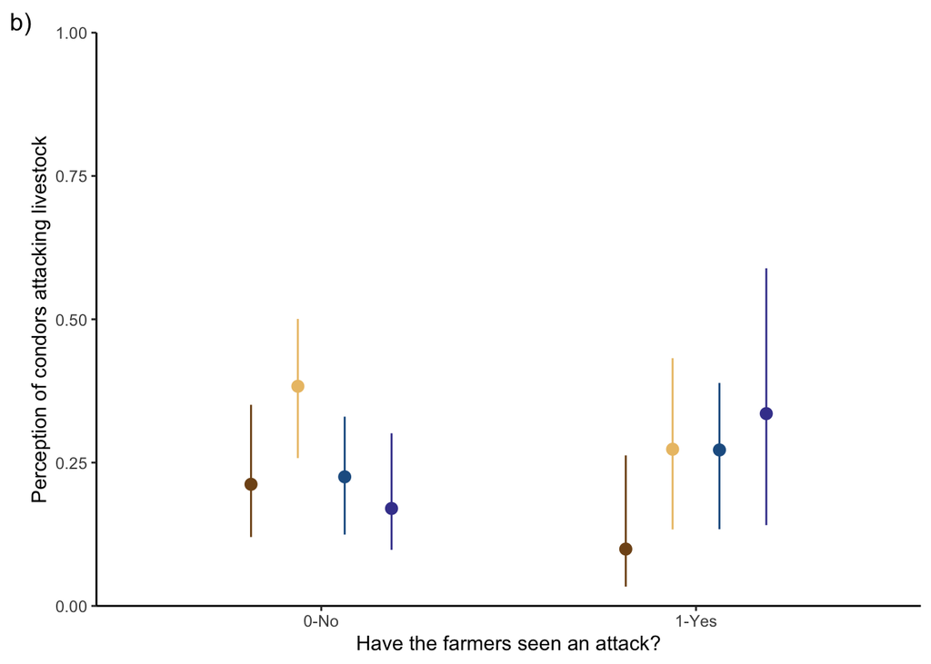

```r
newdat_m3 <- expand.grid(
  seen.attack = levels(as.factor(perceptions_Y3$seen.attack))
)

# simulate data
nsim = 1000

# extract coefficients and vcov
coefs.m3 <- c(coef(mods_perceptions_expatt$seen.attack), # slope
                 mods_perceptions_expatt$seen.attack$zeta) # thresholds
vc.m3 <- vcov(mods_perceptions_expatt$seen.attack)
vc.safe.m3 <- as.matrix(Matrix::nearPD(vc.m3)$mat)

# simulate parameter sets
sim_coefs.m3 <- mvrnorm(nsim, mu = coefs.m3, Sigma = vc.safe.m3)

# predict values from model
pred_list_m3 <- lapply(1:nsim, function(i) {
  predict_from_params(sim_coefs.m3[i,], newdat_m3, mods_perceptions_expatt$seen.attack)
})

pred_array_m3 <- simplify2array(pred_list_m3)
# dim: [ row, category, simulation ] = 100 (as in newdat_m2) x 4 ordinal outcomes (Never, Rarely, Sometimes, Often) x 1000 simulations

# summarizing and CI across simualtions
med_m3 <- apply(pred_array_m3, c(1, 2), median)
low_m3 <- apply(pred_array_m3, c(1, 2), quantile, 0.025)
upp_m3 <- apply(pred_array_m3, c(1, 2), quantile, 0.975)

# dim: [ row, category ] = 100 x 4

colnames(med_m3) <- c(paste("med_m3",colnames(med_m3)))
colnames(low_m3) <- c(paste("low_m3",colnames(low_m3)))
colnames(upp_m3) <- c(paste("upp_m3",colnames(upp_m3)))

pred_m3 <- cbind(newdat_m3, med_m3, low_m3, upp_m3)

# convert to long format
pred_m3_long <- pred_m3 |>
  pivot_longer(
    cols = starts_with(c("med_m3", "low_m3", "upp_m3")),
    names_to = c("stat", "cat"),
    names_pattern = "(med_m3|low_m3|upp_m3) (\\d)",
    values_to = "value"
  ) |>
  mutate(Category = recode(cat,
                      "0" = "Never",
                      "1" = "Rarely",
                      "2" = "Sometimes",
                      "3" = "Often"),
         Category = factor(Category,
                              levels = c("Never",
                                         "Rarely",
                                         "Sometimes",
                                         "Often"))) |>
  dplyr::select(-cat) |>
  pivot_wider(
    names_from = stat,
    values_from = value,
    names_prefix = ""
  ) |>
  rename(
    median = `med_m3`,
    lower  = `low_m3`,
    upper  = `upp_m3`
  )

p_seen <- ggplot(pred_m3_long, aes(x = seen.attack,
                         y = median,
                         color = Category)) +
  geom_pointrange(aes(ymin = lower, ymax = upper), position = position_dodge(width = 0.5))+
  scale_y_continuous(expand = c(0,0),
                     limits = c(0,1))+
  scale_color_manual(values = met.brewer("Manet",4))+
  labs(x = "Have the farmers seen an attack?",
       y = "Perception of condors attacking livestock",
       tag = "b)")+
  theme_classic()+
  theme(legend.position = "none")
p_seen
```

Combine the figures

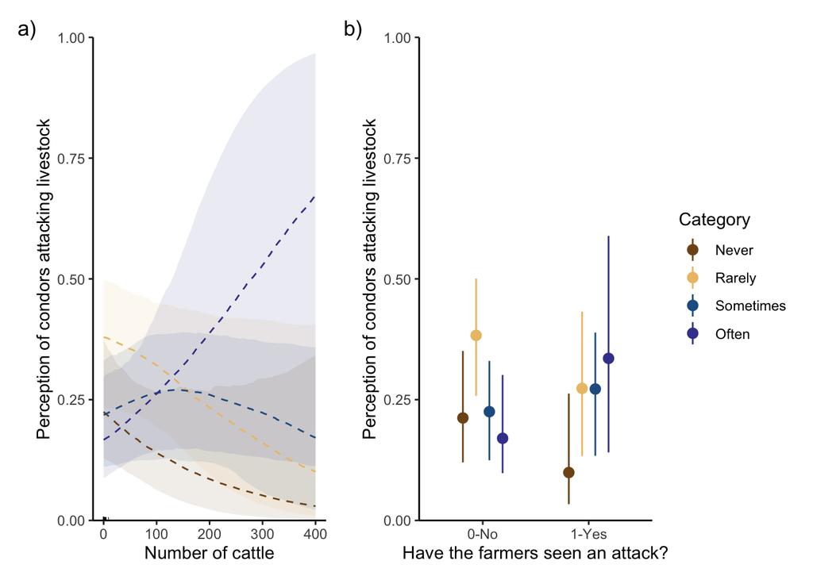

```r
(p_cattle | p_seen) +
  plot_layout(guides = "collect") +
  theme(
    legend.position = "bottom",
    legend.direction = "vertical"
  )
```

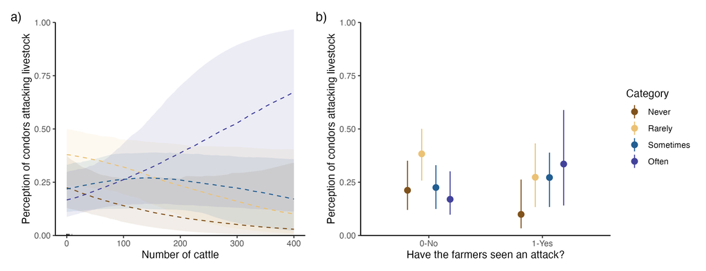

**Perpection of attacts perceived by farm characteristics and experiences.** No clear relationship of variables related with the predicted probability of perceibing condors attacking livestock (models selected with AICc). This probability is ordered by the ordinal perception of condors attacking livestock Never, Rarely, Sometimes, and Often (colors). Variation represents 95% confidence intervals as a measure of uncertainty after 1000 simulation of the parameters. Two predictors selected to illustrate this unclear relationship, number of cattle for farm characteristics (a), and have seen an attack by farmers (b)

```r
ggsave(filename = "figs/Fig_Aim1_b_c_perception.jpg", dpi = 300,
       width = 260, height = 100, units = "mm")
```

# 4 Perception of harmfulness or mixed compared to beneficial (aim 2)

Farmers perceive the Andean condor as beneficial, harmfulness, or a combination (mixed perception). However, these perceptions vary with socio-demographic, farm characteristics, and experience/attitudes

## 4.1 Perception of harmfulness or mixed compared to beneficial predicted by socio-demographic (2a)

This is a nominal outcome, without an specific order (Beneficial, Harmful, Both)

```r
perceptions_Y4 <- perceptions |>
  mutate(Y_benefit = ifelse(`Could you indicate if the Andean condor is beneficial and/or harmful to you?` == 0, "Harmful",
                     ifelse(`Could you indicate if the Andean condor is beneficial and/or harmful to you?` == 1, "Beneficial",
                     ifelse(`Could you indicate if the Andean condor is beneficial and/or harmful to you?` == 2, "Both",
                            NA))),
         Y_benefit = factor(Y_benefit,
                            levels = c("Beneficial",
                                       "Harmful",
                                       "Both")),
         site = as.factor(ifelse(`Paddock site` == 0, "Antisana",
                       "Llanganates")),
         gender = as.factor(ifelse(Gender == 0, "Male", "Female")),
         age = Age,
         edu.level = factor(`Education level`,
                       levels = 0:4,
                       labels = c("0-None","1-Prim","2-High","3-Tech","4-Univ")),
         t.residence = `Time of residence`,
         occupation = as.factor(ifelse(Occupation == 0, "Employer","Owner")))

# sequencial contrast for education level
contrasts(perceptions_Y4$edu.level) <- MASS::contr.sdif(5)

# a list of ordered logistic regression
mods_benefit_demogra <- list(
  null =  multinom(Y_benefit ~ 1,  data = perceptions_Y4),
  site  = multinom(Y_benefit ~ site,  data = perceptions_Y4),
  gender  = multinom(Y_benefit ~ gender,  data = perceptions_Y4),
  age   = multinom(Y_benefit ~ age,  data = perceptions_Y4),
  edu.level  = multinom(Y_benefit ~ edu.level,  data = perceptions_Y4),
  t.residence  = multinom(Y_benefit ~ t.residence,  data = perceptions_Y4),
  occupation   = multinom(Y_benefit ~ occupation,  data = perceptions_Y4),
  global = multinom(Y_benefit ~ site + gender + age + edu.level + t.residence + occupation, data = perceptions_Y4),
  # after two models within deltaAICc < 2
  site.tres = multinom(Y_benefit ~ site + t.residence, data = perceptions_Y4),
  site.tres.int = multinom(Y_benefit ~ site + t.residence + site*t.residence, data = perceptions_Y4)
  )
AICcmodavg::aictab(mods_benefit_demogra) # site, t.residence, and null; when adding
```

```
##
## Model selection based on AICc:
##
##                K   AICc Delta_AICc AICcWt Cum.Wt     LL
## site           4 117.93       0.00   0.26   0.26 -54.59
## site.tres      6 118.29       0.35   0.22   0.48 -52.32
## t.residence    4 118.52       0.59   0.20   0.68 -54.88
## null           2 118.65       0.71   0.18   0.86 -57.21
## site.tres.int  8 120.49       2.56   0.07   0.94 -50.78
## age            4 122.90       4.96   0.02   0.96 -57.07
## occupation     4 122.90       4.97   0.02   0.98 -57.07
## gender         4 123.08       5.15   0.02   1.00 -57.17
## edu.level     10 130.75      12.81   0.00   1.00 -53.03
## global        20 156.52      38.59   0.00   1.00 -46.91
```

```r
summary(mods_benefit_demogra$site.tres)
```

```
## Call:
## multinom(formula = Y_benefit ~ site + t.residence, data = perceptions_Y4)
##
## Coefficients:
##         (Intercept) siteLlanganates t.residence
## Harmful  -0.9396415       1.3504808  0.02965201
## Both     -0.1025638      -0.1045128  0.03807616
##
## Std. Errors:
##         (Intercept) siteLlanganates t.residence
## Harmful   0.8380127        0.953358  0.02125453
## Both      0.7026429        0.938704  0.01906071
##
## Residual Deviance: 104.6392
## AIC: 116.6392
```

To get the p-values

```r
z_benef <- summary(mods_benefit_demogra$site.tres)$coefficients / summary(mods_benefit_demogra$site.tres)$standard.errors
pvals_benef <- 2 * (1 - pnorm(abs(z_benef)))
pvals_benef
```

```
##         (Intercept) siteLlanganates t.residence
## Harmful   0.2621714       0.1566141  0.16298841
## Both      0.8839462       0.9113488  0.04575735
```

Our research question for the model was “What socio-demographic factor makes farmers perceive condors as harmful or both harmful and beneficial, instead of only beneficial?” Farmers who have lived longer in the area are more likely to report a mixed perception (both beneficial and harmful) compared to beneficial. Although farmers in Llanganates tend to be more likely to perceive the condor as harmful than beneficial, the uncertainty is too large and not statistically supported.

Plot the results with a new dataset for predictions

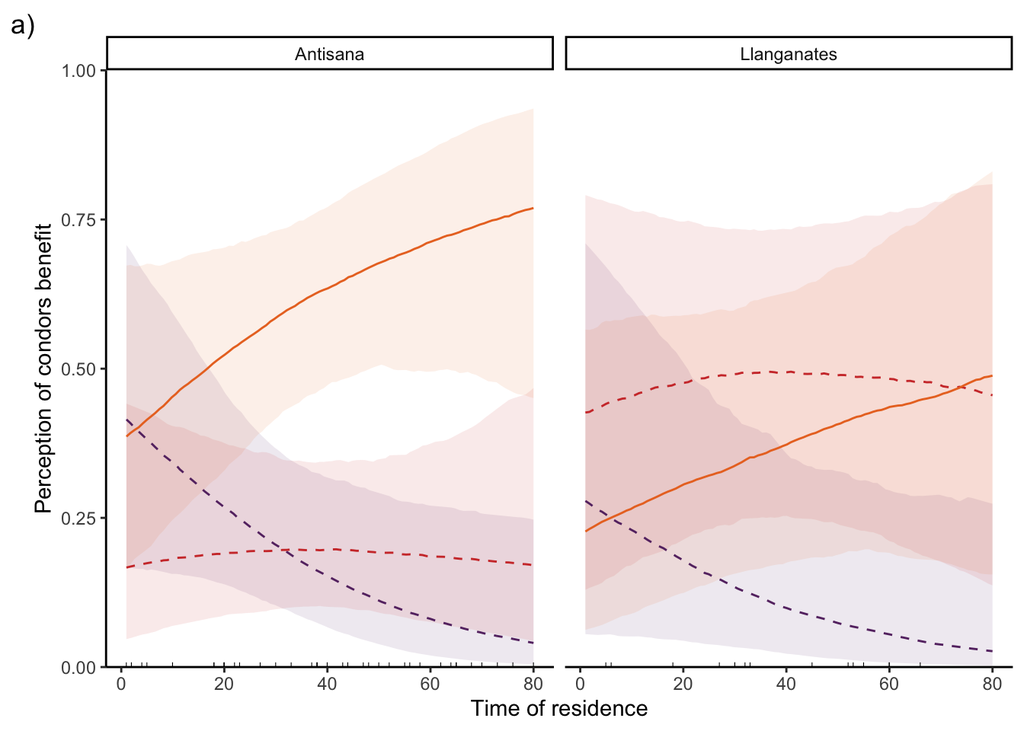

```r
newdat_m4 <- expand.grid(
  site = levels(as.factor(perceptions_Y4$site)),
  t.residence = seq(min(perceptions_Y4$t.residence),
                    max(perceptions_Y4$t.residence),
                    length = 100)
)

# simulate data
nsim = 1000

# extract coefficients and vcov
coefs.m4 <- as.vector(t(coef(mods_benefit_demogra$site.tres)))
vc.m4 <- vcov(mods_benefit_demogra$site.tres)
vc.safe.m4 <- as.matrix(Matrix::nearPD(vc.m4)$mat)

# simulate parameter sets
sim_coefs.m4 <- mvrnorm(nsim, mu = coefs.m4, Sigma = vc.safe.m4)

# predict values from model
pred_list_m4 <- lapply(1:nsim, function(i) {
  predict_multinom_params(sim_coefs.m4[i,], newdat_m4, mods_benefit_demogra$site.tres)
})

pred_array_m4 <- simplify2array(pred_list_m4)
# dim: [ row, category, simulation ] = 200 (as in newdat_m4) x 3 levels (Beneficial, Both, harmful) x 1000 simulations

# summarizing and CI across simualtions
med_m4 <- apply(pred_array_m4, c(1, 2), median)
low_m4 <- apply(pred_array_m4, c(1, 2), quantile, 0.025)
upp_m4 <- apply(pred_array_m4, c(1, 2), quantile, 0.975)

# dim: [ row, category ] = 200 x 3

colnames(med_m4) <- c(paste("med_m4",colnames(med_m4)))
colnames(low_m4) <- c(paste("low_m4",colnames(low_m4)))
colnames(upp_m4) <- c(paste("upp_m4",colnames(upp_m4)))

pred_m4 <- cbind(newdat_m4, med_m4, low_m4, upp_m4)

# convert to long format
pred_m4_long <- pred_m4 |>
  pivot_longer(
    cols = starts_with(c("med_m4", "low_m4", "upp_m4")),
    names_to = c("stat", "Category"),
    names_pattern = "(med_m4|low_m4|upp_m4) (.*)",
    values_to = "value"
  ) |>
  pivot_wider(
    names_from = stat,
    values_from = value
  ) |>
  rename(
    median = med_m4,
    lower  = low_m4,
    upper  = upp_m4
  ) |>
  mutate(
    Category = factor(Category,
                      levels = c("Beneficial", "Harmful", "Both"))
  )

# visually representing the results of the model
linetypes_m4 <- c(
  "Beneficial" = "dashed",
  "Harmful"    = "dashed",
  "Both"       = "solid"
)


per_m4 <- ggplot(pred_m4_long,
       aes(x = t.residence, y = median)) +
  facet_wrap(~site)+
  geom_ribbon(aes(ymin = lower, ymax = upper, fill = Category), alpha = 0.1)+
  geom_line(aes(color = Category, linetype = Category))+
  geom_point(data = perceptions_Y4, aes(x = t.residence, y = 0), shape = "|", fill = "black")+
  scale_y_continuous(limits = c(0,1), expand = c(0,0)) +
  scale_linetype_manual(values = linetypes_m4) +
  scale_color_manual(values = met.brewer("Java"))+
  scale_fill_manual(values = met.brewer("Java"))+
  labs(x = "Time of residence",
       y = "Perception of condors benefit",
       tag = "a)") +
  theme_classic() +
  theme(legend.position = "none")
per_m4
```

## 4.2 Perception of harmfulness or mixed compared to beneficial predicted by farm characteristics (2b)

This is a nominal outcome, without an specific order (Beneficial, Harmful, Both)

```r
perceptions_Y5 <- perceptions |>
  mutate(Y_benefit = ifelse(`Could you indicate if the Andean condor is beneficial and/or harmful to you?` == 0, "Harmful",
                     ifelse(`Could you indicate if the Andean condor is beneficial and/or harmful to you?` == 1, "Beneficial",
                     ifelse(`Could you indicate if the Andean condor is beneficial and/or harmful to you?` == 2, "Both",
                            NA))),
         Y_benefit = factor(Y_benefit,
                            levels = c("Beneficial",
                                       "Harmful",
                                       "Both")),
         t.livestock = factor(ifelse(`Type of livestock`== 0, "0-Cattle",
                       ifelse(`Type of livestock`==1, "1-Other",
                       ifelse(`Type of livestock`==2,"1-Other",
                       ifelse(`Type of livestock`==3, "1-Other",
                       ifelse(`Type of livestock`==4, "1-Other",
                       ifelse(`Type of livestock`==5, "1-Other",
                       ifelse(`Type of livestock`==6, "1-Other",
                       NA)))))))),
         n.cattle = ifelse(is.na(Cattle), 0, Cattle),
         n.horses = ifelse(is.na(Horse), 0, Horse),
         n.sheep = ifelse(is.na(Sheep), 0, Sheep),
         n.lama = ifelse(is.na(Lama), 0, Lama),
         t.production = factor(ifelse(`Type of cattle production`== 0, "0-Beef",
                                    ifelse(`Type of cattle production`==1, "1-Dairy",
                                    ifelse(`Type of cattle production`==2,"2-Brave",
                                    ifelse(`Type of cattle production`==3, "3-Multiple",
                                    ifelse(`Type of cattle production`==4, "3-Multiple",
                                    ifelse(`Type of cattle production`==5, "3-Multiple",
                                    NA))))))))

# a list of ordered logistic regression
mods_benefit_farm <- list(
  null =  multinom(Y_benefit ~ 1,  data = perceptions_Y5),
  t.livestock  = multinom(Y_benefit ~ t.livestock,  data = perceptions_Y5),
  n.cattle  = multinom(Y_benefit ~ n.cattle,  data = perceptions_Y5),
  n.horses   = multinom(Y_benefit ~ n.horses,  data = perceptions_Y5),
  n.sheep  = multinom(Y_benefit ~ n.sheep,  data = perceptions_Y5),
  n.lama  = multinom(Y_benefit ~ n.lama,  data = perceptions_Y5),
  # as farmers include combination of livestock, we can include these additive potential effects
  n.cattle.horse = multinom(Y_benefit ~ n.cattle + n.horses,  data = perceptions_Y5),
  n.cattle.horse.sheep = multinom(Y_benefit ~ n.cattle + n.horses + n.sheep,  data = perceptions_Y5),
  n.cattle.lama = multinom(Y_benefit ~ n.cattle + n.lama,  data = perceptions_Y5),
  t.production   = multinom(Y_benefit ~ t.production,  data = perceptions_Y5),
  global = multinom(Y_benefit ~ t.livestock+n.cattle+n.horses+ t.production,
                    data = perceptions_Y5)
  )
AICcmodavg::aictab(mods_benefit_farm) # n.cattle.horse, n. horses, n. sheeps
```

```
##
## Model selection based on AICc:
##
##                       K   AICc Delta_AICc AICcWt Cum.Wt     LL
## n.horses              4 114.82       0.00   0.31   0.31 -53.03
## n.sheep               4 115.05       0.23   0.28   0.59 -53.15
## n.cattle.horse.sheep  8 115.88       1.06   0.18   0.77 -48.47
## n.cattle.horse        6 116.23       1.41   0.15   0.92 -51.29
## null                  2 118.65       3.83   0.05   0.97 -57.21
## t.livestock           4 120.84       6.02   0.02   0.98 -56.04
## n.cattle              4 122.39       7.56   0.01   0.99 -56.82
## n.lama                4 122.47       7.65   0.01   1.00 -56.86
## t.production          8 123.91       9.09   0.00   1.00 -52.49
## n.cattle.lama         6 126.53      11.70   0.00   1.00 -56.44
## global               14 127.09      12.27   0.00   1.00 -44.66
```

```r
summary(mods_benefit_farm$n.horses)
```

```
## Call:
## multinom(formula = Y_benefit ~ n.horses, data = perceptions_Y5)
##
## Coefficients:
##         (Intercept)  n.horses
## Harmful   0.2570214 0.0881120
## Both      0.4450434 0.1911706
##
## Std. Errors:
##         (Intercept)  n.horses
## Harmful    0.484642 0.1200132
## Both       0.460967 0.1117600
##
## Residual Deviance: 106.0676
## AIC: 114.0676
```

To get the p-values

```r
z_benef_farm <- summary(mods_benefit_farm$n.horses)$coefficients / summary(mods_benefit_farm$n.horses)$standard.errors
pvals_benef_farm <- 2 * (1 - pnorm(abs(z_benef_farm)))
pvals_benef_farm
```

```
##         (Intercept)   n.horses
## Harmful   0.5958815 0.46283549
## Both      0.3343164 0.08716503
```

Our research question for the model was “What farm characteristic predictor makes farmers perceive condors as harmful or both harmful and beneficial, instead of only beneficial?” Many models are equally possible. For simplicity, we can pickup the number of horses, which had the highest weight.

Plot the results with a new dataset for predictions using the covariate.

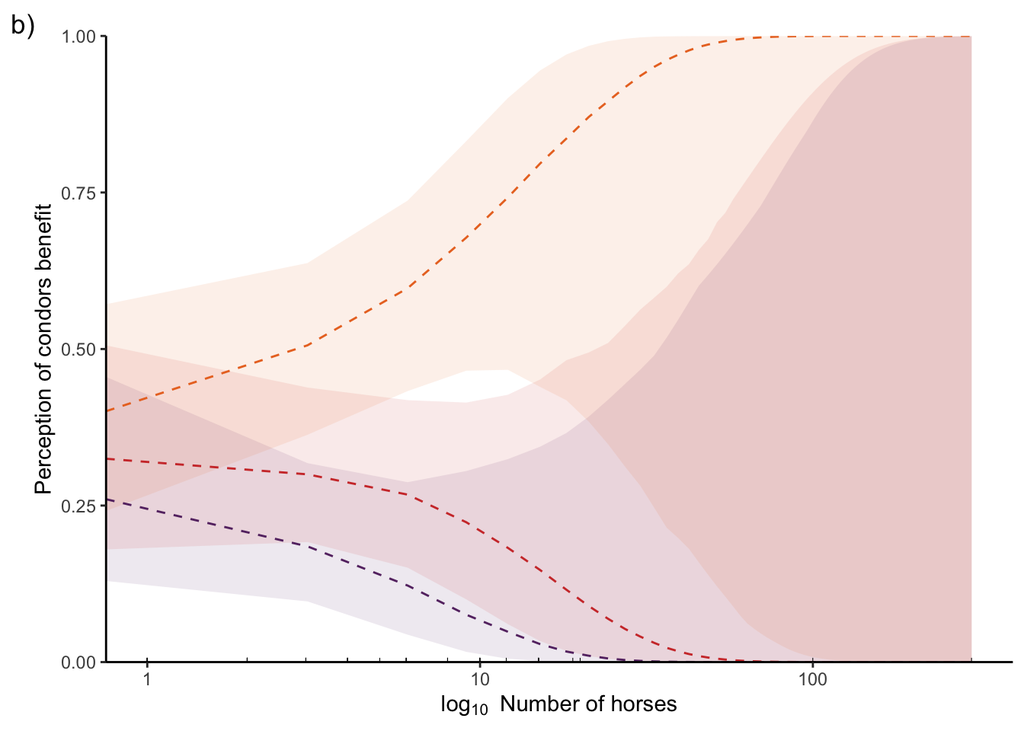

```r
newdat_m5 <- expand.grid(
  n.horses= seq(min(perceptions_Y5$n.horses),
                    max(perceptions_Y5$n.horses),
                    length = 100)
  )

# simulate data
nsim = 1000

# extract coefficients and vcov
coefs.m5 <- as.vector(t(coef(mods_benefit_farm$n.horses)))
vc.m5 <- vcov(mods_benefit_farm$n.horses)
vc.safe.m5 <- as.matrix(Matrix::nearPD(vc.m5)$mat)

# simulate parameter sets
sim_coefs.m5 <- mvrnorm(nsim, mu = coefs.m5, Sigma = vc.safe.m5)

# predict values from model
pred_list_m5 <- lapply(1:nsim, function(i) {
  predict_multinom_params(sim_coefs.m5[i,], newdat_m5, mods_benefit_farm$n.horses)
})

pred_array_m5 <- simplify2array(pred_list_m5)

# summarizing and CI across simualtions
med_m5 <- apply(pred_array_m5, c(1, 2), median)
low_m5 <- apply(pred_array_m5, c(1, 2), quantile, 0.025)
upp_m5 <- apply(pred_array_m5, c(1, 2), quantile, 0.975)

colnames(med_m5) <- c(paste("med_m5",colnames(med_m5)))
colnames(low_m5) <- c(paste("low_m5",colnames(low_m5)))
colnames(upp_m5) <- c(paste("upp_m5",colnames(upp_m5)))

pred_m5 <- cbind(newdat_m5, med_m5, low_m5, upp_m5)

# convert to long format
pred_m5_long <- pred_m5 |>
  pivot_longer(
    cols = starts_with(c("med_m5", "low_m5", "upp_m5")),
    names_to = c("stat", "Category"),
    names_pattern = "(med_m5|low_m5|upp_m5) (.*)",
    values_to = "value"
  ) |>
  pivot_wider(
    names_from = stat,
    values_from = value
  ) |>
  rename(
    median = med_m5,
    lower  = low_m5,
    upper  = upp_m5
  ) |>
  mutate(
    Category = factor(Category,
                      levels = c("Beneficial", "Harmful", "Both"))
  )


per_m5 <- ggplot(pred_m5_long,
       aes(x = n.horses, y = median)) +
  geom_ribbon(aes(ymin = lower, ymax = upper, fill = Category), alpha = 0.1)+
  geom_line(aes(color = Category), linetype = "dashed")+
  geom_point(data = perceptions_Y5, aes(x = n.horses, y = 0), shape = "|", fill = "black")+
  scale_x_log10()+
  scale_y_continuous(limits = c(0,1), expand = c(0,0)) +
  scale_color_manual(values = met.brewer("Java"))+
  scale_fill_manual(values = met.brewer("Java"))+
  labs(x = expression(log[10]~" Number of horses"),
       y = "Perception of condors benefit",
       tag = "b)") +
  theme_classic() +
  theme(legend.position = "none")
per_m5
```

## 4.3 Perception of harmfulness or mixed compared to beneficial predicted by experiences/attitudes (2c)

This is a nominal outcome, without an specific order (Beneficial, Harmful, Both)

```r
perceptions_Y6 <- perceptions |>
  mutate(Y_benefit = ifelse(`Could you indicate if the Andean condor is beneficial and/or harmful to you?` == 0, "Harmful",
                     ifelse(`Could you indicate if the Andean condor is beneficial and/or harmful to you?` == 1, "Beneficial",
                     ifelse(`Could you indicate if the Andean condor is beneficial and/or harmful to you?` == 2, "Both",
                            NA))),
         Y_benefit = factor(Y_benefit,
                            levels = c("Beneficial",
                                       "Harmful",
                                       "Both")),
         seen.attack = ifelse(`Have you ever seen condors attacking living livestock?` == 0, "1-Yes",
                       "0-No"),
         perc.popcha = ifelse(`Do you consider that the Andean condor population in this area?`== 0, "0-Decreased",
                       ifelse(`Do you consider that the Andean condor population in this area?`== 1, "0-Decreased",
                       ifelse(`Do you consider that the Andean condor population in this area?`== 2, "1-Remains stable",
                       ifelse(`Do you consider that the Andean condor population in this area?`== 3, "2-Increased",
                       ifelse(`Do you consider that the Andean condor population in this area?`== 4, "2-Increased",
                       NA))))),
         atti.feeling = ifelse(`What are your feelings towards Andean condors?`== 0, "4-Like a lot",
                       ifelse(`What are your feelings towards Andean condors?`== 1, "3-Like",
                       ifelse(`What are your feelings towards Andean condors?`== 2, "2-Indifferent",
                       ifelse(`What are your feelings towards Andean condors?`== 3, "1-Dislike",
                       ifelse(`What are your feelings towards Andean condors?`== 4, "0-Dislike a lot",
                       NA))))),
         atti.dissap = ifelse(`What would you feel if all of the condors disappeared forever from the region?`== 0, "0-Very happy",
                       ifelse(`What would you feel if all of the condors disappeared forever from the region?`== 1, "1-Happy",
                       ifelse(`What would you feel if all of the condors disappeared forever from the region?`== 2, "2-Indifferent",
                       ifelse(`What would you feel if all of the condors disappeared forever from the region?`== 3, "3-Sad",
                       ifelse(`What would you feel if all of the condors disappeared forever from the region?`== 4, "4-Very sad",
                       NA))))),
         atti.popcha = ifelse(`Would you like the Andean condor population in the National Park and the surrounding area to?`== 0, "0-Decreased",
                       ifelse(`Would you like the Andean condor population in the National Park and the surrounding area to?`== 1, "0-Decreased",
                       ifelse(`Would you like the Andean condor population in the National Park and the surrounding area to?`== 2, "1-Remains stable",
                       ifelse(`Would you like the Andean condor population in the National Park and the surrounding area to?`== 3, "2-Increased",
                       ifelse(`Would you like the Andean condor population in the National Park and the surrounding area to?`== 4, "2-Increased",
                       NA))))),
         perc.attack = ifelse(`Do you think condors attack living livestock?` == 0, "0-Never",
                           ifelse(`Do you think condors attack living livestock?` == 1, "1-Rarely",
                           ifelse(`Do you think condors attack living livestock?` == 2, "2-Sometimes",
                           ifelse(`Do you think condors attack living livestock?` == 3, "3-Often",NA)))),
         # reorder binomial (0 = No, 1 = Yes)
    workshop = ifelse(`Have you attended talks/trainings on the environment?` == 0, 1, 0)
         )

# a list of ordered logistic regression
mods_benefit_att <- list(
  null =  multinom(Y_benefit ~ 1,  data = perceptions_Y6),
  seen.attack = multinom(Y_benefit ~ seen.attack, data = perceptions_Y6),
  perc.popcha = multinom(Y_benefit ~ perc.popcha, data = perceptions_Y6),
  atti.feeling = multinom(Y_benefit ~ atti.feeling, data = perceptions_Y6),
  atti.dissap = multinom(Y_benefit ~ atti.dissap, data = perceptions_Y6),
  atti.popcha = multinom(Y_benefit ~ atti.popcha, data = perceptions_Y6),
  perc.attack = multinom(Y_benefit ~ perc.attack, data = perceptions_Y6),
  workshop = multinom(Y_benefit ~ workshop, data = perceptions_Y6),
  global = multinom(Y_benefit ~ seen.attack + perc.popcha + atti.feeling + atti.dissap + atti.popcha + perc.attack + workshop, data = perceptions_Y6)
  )
AICcmodavg::aictab(mods_benefit_att) # perc.attack
```

```
##
## Model selection based on AICc:
##
##               K   AICc Delta_AICc AICcWt Cum.Wt     LL
## perc.attack   8  80.50       0.00      1      1 -30.78
## workshop      4 117.26      36.77      0      1 -54.25
## null          2 118.65      38.15      0      1 -57.21
## seen.attack   4 118.92      38.43      0      1 -55.08
## atti.popcha   6 124.82      44.32      0      1 -55.59
## perc.popcha   6 125.32      44.83      0      1 -55.84
## atti.dissap  10 131.25      50.75      0      1 -53.28
## atti.feeling 10 132.46      51.96      0      1 -53.89
## global       36 230.12     149.62      0      1 -15.63
```

```r
summary(mods_benefit_att$perc.attack)
```

```
## Call:
## multinom(formula = Y_benefit ~ perc.attack, data = perceptions_Y6)
##
## Coefficients:
##         (Intercept) perc.attack1-Rarely perc.attack2-Sometimes
## Harmful   -2.301078            13.17125               10.88795
## Both     -11.879557            23.44299               22.25804
##         perc.attack3-Often
## Harmful           11.99213
## Both              21.57070
##
## Std. Errors:
##         (Intercept) perc.attack1-Rarely perc.attack2-Sometimes
## Harmful    1.048166             86.6826               51.78559
## Both     120.128404            148.1335              130.80927
##         perc.attack3-Often
## Harmful           51.93117
## Both             130.86856
##
## Residual Deviance: 61.55627
## AIC: 77.55627
```

To get the p-values

```r
z_benef_att <- summary(mods_benefit_att$perc.attack)$coefficients / summary(mods_benefit_att$perc.attack)$standard.errors
pvals_benef_att <- 2 * (1 - pnorm(abs(z_benef_att)))
pvals_benef_att
```

```
##         (Intercept) perc.attack1-Rarely perc.attack2-Sometimes
## Harmful  0.02813938           0.8792279              0.8334721
## Both     0.92122522           0.8742552              0.8648871
##         perc.attack3-Often
## Harmful          0.8173743
## Both             0.8690800
```

Plot the results with a new dataset for predictions using the covariate.

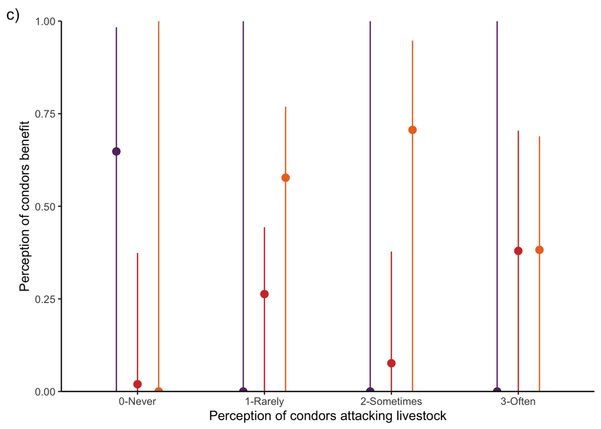

```r
newdat_m6 <- expand.grid(
  perc.attack= levels(factor(perceptions_Y6$perc.attack))
  )

# simulate data
nsim = 1000

# extract coefficients and vcov
coefs.m6 <- as.vector(t(coef(mods_benefit_att$perc.attack)))
vc.m6 <- vcov(mods_benefit_att$perc.attack)
vc.safe.m6 <- as.matrix(Matrix::nearPD(vc.m6)$mat)

# simulate parameter sets
sim_coefs.m6 <- mvrnorm(nsim, mu = coefs.m6, Sigma = vc.safe.m6)

# predict values from model
pred_list_m6 <- lapply(1:nsim, function(i) {
  predict_multinom_params(sim_coefs.m6[i,], newdat_m6, mods_benefit_att$perc.attack)
})

pred_array_m6 <- simplify2array(pred_list_m6)

# summarizing and CI across simualtions
med_m6 <- apply(pred_array_m6, c(1, 2), median)
low_m6 <- apply(pred_array_m6, c(1, 2), quantile, 0.025)
upp_m6 <- apply(pred_array_m6, c(1, 2), quantile, 0.975)

colnames(med_m6) <- c(paste("med_m6",colnames(med_m6)))
colnames(low_m6) <- c(paste("low_m6",colnames(low_m6)))
colnames(upp_m6) <- c(paste("upp_m6",colnames(upp_m6)))

pred_m6 <- cbind(newdat_m6, med_m6, low_m6, upp_m6)

# convert to long format
pred_m6_long <- pred_m6 |>
  pivot_longer(
    cols = starts_with(c("med_m6", "low_m6", "upp_m6")),
    names_to = c("stat", "Category"),
    names_pattern = "(med_m6|low_m6|upp_m6) (.*)",
    values_to = "value"
  ) |>
  pivot_wider(
    names_from = stat,
    values_from = value
  ) |>
  rename(
    median = med_m6,
    lower  = low_m6,
    upper  = upp_m6
  ) |>
  mutate(
    Category = factor(Category,
                      levels = c("Beneficial", "Harmful", "Both"))
  )


per_m6 <- ggplot(pred_m6_long,
       aes(x = perc.attack, y = median)) +
  geom_pointrange(aes(ymin = lower, ymax = upper, color = Category),
                  position = position_dodge(width = 0.5))+
  scale_y_continuous(limits = c(0,1), expand = c(0,0)) +
  scale_color_manual(values = met.brewer("Java"))+
  scale_fill_manual(values = met.brewer("Java"))+
  labs(x = "Perception of condors attacking livestock",
       y = "Perception of condors benefit",
       tag = "c)") +
  theme_classic() +
  theme(legend.position = "none")
per_m6
```

Combine the figures

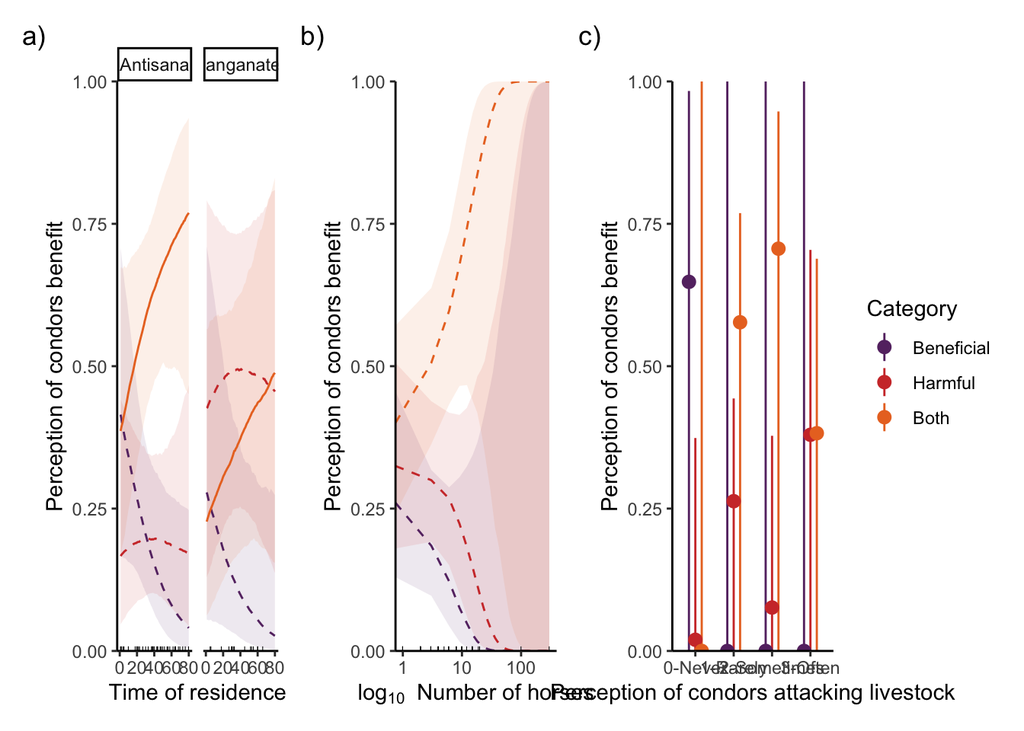

```r
(per_m4 | per_m5 | per_m6) +
  plot_layout(guides = "collect") +
  theme(
    legend.position = "bottom",
    legend.direction = "vertical"
  )
```

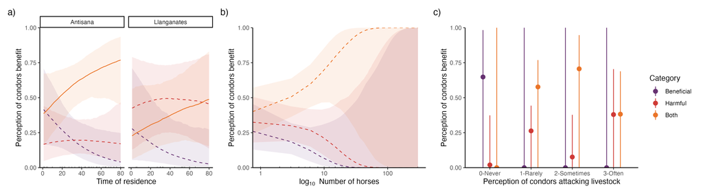

```r
ggsave(filename = "figs/Fig_Aim2_a_b_c_perception.jpg", dpi = 300,
       width = 360, height = 100, units = "mm")
```

# 5 Coexistence behaviors (aim 3)

Here, there are two important behaviors: “leaving carcasses in the field to be consumed by condors” and “educating others about the importance of condor conservation” (Binary outcomes: Logistic regression). The predictors for these behaviors could be “perceived contributions” (beneficial, harmful, both), “attendance at workshops” (yes, no), and “perceptions of population change” (decreased a lot, decreased, remains the same, increased, increased a lot).

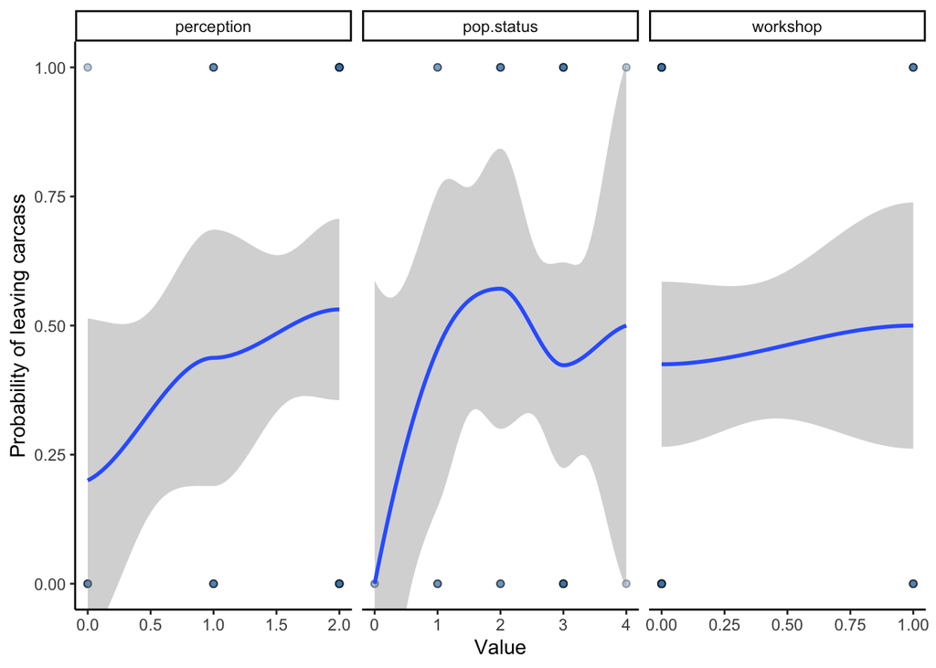

```r
perceptions_coex <- perceptions |>
  mutate(
    # reorder binomial (0 = No, 1= yes)
    leave = ifelse(`Do you leave livestock carcasses in the field to be consumed by condors?` == 0, 1, 0),
    # reorder binomial (0 = No, 1= yes)
    educate = ifelse(`Do you educate others about the importance of Andean condor conservation?` == 0, 1, 0),
    # reorder as in previous analysis (0 = beneficial, 1 = harmful, 2 = both)
    perception = ifelse(`Could you indicate if the Andean condor is beneficial and/or harmful to you?` == 1, 0,
                 ifelse(`Could you indicate if the Andean condor is beneficial and/or harmful to you?` == 2, 2, 1)),
    pop.status = `Do you consider that the Andean condor population in this area?`,
    # reorder binomial (0 = No, 1 = Yes)
    workshop = ifelse(`Have you attended talks/trainings on the environment?` == 0, 1, 0))

perceptions_long <- perceptions_coex %>%
  dplyr::select(leave, educate,
                perception, workshop, pop.status) %>%
  pivot_longer(-c(leave, educate),
               names_to = "Variable",
               values_to = "Value")

# exploratory plots
ggplot(perceptions_long, aes(x = Value, y = leave)) +
  geom_point(alpha = 0.2, fill = "steelblue", shape = 21) +
  geom_smooth()+
  facet_wrap(~ Variable, scales = "free_x") +
  labs(x = "Value", y = "Probability of leaving carcass") +
  theme_classic() +
  coord_cartesian(ylim = c(0,1))
```

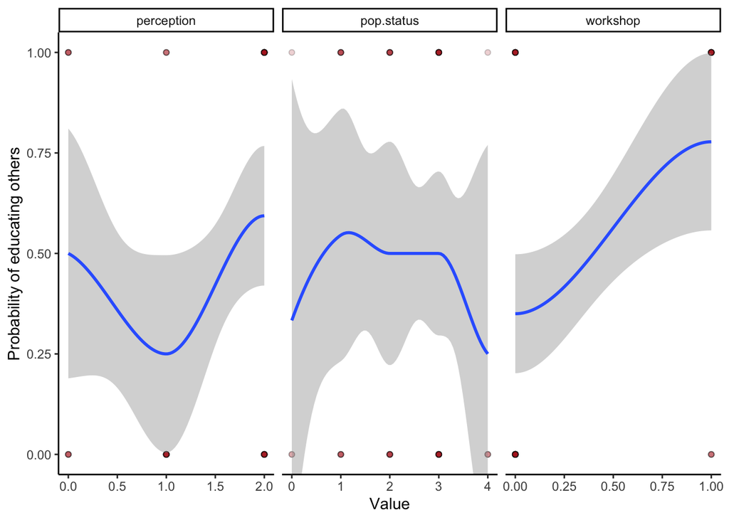

```r
ggplot(perceptions_long, aes(x = Value, y = educate)) +
  geom_point(alpha = 0.2, fill = "firebrick", shape = 21) +
  geom_smooth()+
  facet_wrap(~ Variable, scales = "free_x") +
  labs(x = "Value", y = "Probability of educating others") +
  theme_classic() +
  coord_cartesian(ylim = c(0,1))
```

And model selection. First for leaving carcasses

```r
mods_leave <- list(
  null       = logistf(leave ~ 1, data = perceptions_coex),
  perception = logistf(leave ~ perception, data = perceptions_coex),
  workshop   = logistf(leave ~ workshop, data = perceptions_coex),
  popstatus  = logistf(leave ~ pop.status, data = perceptions_coex),
  percep2    = logistf(leave ~ perception + I(perception^2), data = perceptions_coex),
  pop2       = logistf(leave ~ pop.status + I(pop.status^2), data = perceptions_coex),
  global     = logistf(leave ~ perception + I(perception^2) + workshop + pop.status + I(pop.status^2), data = perceptions_coex)
)

aic_table_leave <- lapply(mods_leave, AICc_logistf)
aic_table_leave <- do.call(rbind, aic_table_leave)
aic_table_leave <- aic_table_leave |>
  mutate(dAICc = AICc - min(AICc)) |>
  arrange(dAICc)
aic_table_leave
```

```
##                      AIC     AICc K     dAICc
## perception.full 75.93080 76.14898 2 0.0000000
## pop2.full       75.86819 76.31264 3 0.1636595
## global.full     75.29200 76.93905 6 0.7900758
## percep2.full    76.82151 77.26595 3 1.1169706
## pop2.null       77.48841 77.93285 3 1.7838708
## popstatus.full  78.06781 78.28599 2 2.1370109
## popstatus.null  78.42158 78.63976 2 2.4907855
## null.full       79.11970 79.19113 1 3.0421482
## null.null       79.11970 79.19113 1 3.0421482
## perception.null 79.00005 79.21823 2 3.0692506
## workshop.full   79.71720 79.93538 2 3.7864033
## workshop.null   79.99741 80.21559 2 4.0666092
## percep2.null    80.04563 80.49008 3 4.3410981
## global.null     79.42448 81.07154 6 4.9225585
```

and for educating others

```r
mods_educate <- list(
  null       = logistf(educate ~ 1, data = perceptions_coex),
  perception = logistf(educate ~ perception, data = perceptions_coex),
  workshop   = logistf(educate ~ workshop, data = perceptions_coex),
  popstatus  = logistf(educate ~ pop.status, data = perceptions_coex),
  percep2    = logistf(educate ~ perception + I(perception^2), data = perceptions_coex),
  pop2       = logistf(educate ~ pop.status + I(pop.status^2), data = perceptions_coex),
  global     = logistf(educate ~ perception + I(perception^2) + workshop + pop.status + I(pop.status^2), data = perceptions_coex)
)

aic_table_educa <- lapply(mods_educate, AICc_logistf)
aic_table_educa <- do.call(rbind, aic_table_educa)
aic_table_educa <- aic_table_educa |>
  mutate(dAICc = AICc - min(AICc)) |>
  arrange(dAICc)
aic_table_educa
```

```
##                      AIC     AICc K     dAICc
## global.full     68.48319 70.13025 6  0.000000
## workshop.full   71.49635 71.71453 2  1.584285
## percep2.full    75.62209 76.06653 3  5.936285
## pop2.full       77.07323 77.51768 3  7.387430
## perception.full 78.23856 78.45674 2  8.326493
## pop2.null       78.01394 78.45838 3  8.328136
## popstatus.full  78.86288 79.08106 2  8.950810
## popstatus.null  78.95591 79.17409 2  9.043842
## null.full       79.66311 79.73454 1  9.604296
## null.null       79.66311 79.73454 1  9.604296
## perception.null 79.53437 79.75255 2  9.622307
## workshop.null   80.53173 80.74991 2 10.619666
## percep2.null    80.57117 81.01561 3 10.885363
## global.null     79.92530 81.57235 6 11.442107
```

The behavior of leaving carcass for the condors is weakly related with any hypothesized predictor. The threshold of $\Delta\text{AICc}≤2$ shows that many models, including a “global”, are equal possible. We can see the coefficients for these models, showing the marginal increasing trend with perception.

```r
aic_table_leave
```

```
##                      AIC     AICc K     dAICc
## perception.full 75.93080 76.14898 2 0.0000000
## pop2.full       75.86819 76.31264 3 0.1636595
## global.full     75.29200 76.93905 6 0.7900758
## percep2.full    76.82151 77.26595 3 1.1169706
## pop2.null       77.48841 77.93285 3 1.7838708
## popstatus.full  78.06781 78.28599 2 2.1370109
## popstatus.null  78.42158 78.63976 2 2.4907855
## null.full       79.11970 79.19113 1 3.0421482
## null.null       79.11970 79.19113 1 3.0421482
## perception.null 79.00005 79.21823 2 3.0692506
## workshop.full   79.71720 79.93538 2 3.7864033
## workshop.null   79.99741 80.21559 2 4.0666092
## percep2.null    80.04563 80.49008 3 4.3410981
## global.null     79.42448 81.07154 6 4.9225585
```

```r
summary(mods_leave$perception) # marginal increasing trend
```

```
## logistf(formula = leave ~ perception, data = perceptions_coex)
##
## Model fitted by Penalized ML
## Coefficients:
##                   coef  se(coef)  lower 0.95 upper 0.95    Chisq          p
## (Intercept) -1.0629981 0.5861136 -2.32394994 0.02749686 3.643228 0.05629770
## perception   0.6166873 0.3639930 -0.07121346 1.37981462 3.069251 0.07978624
##             method
## (Intercept)      2
## perception       2
##
## Method: 1-Wald, 2-Profile penalized log-likelihood, 3-None
##
## Likelihood ratio test=3.069251 on 1 df, p=0.07978624, n=58
## Wald test = 3.319123 on 1 df, p = 0.06847834
```

```r
summary(mods_leave$pop2) # no effect
```

```
## logistf(formula = leave ~ pop.status + I(pop.status^2), data = perceptions_coex)
##
## Model fitted by Penalized ML
## Coefficients:
##                       coef se(coef) lower 0.95 upper 0.95    Chisq         p
## (Intercept)     -1.3450993 1.023952 -3.8095533  0.4973191 1.974192 0.1600036
## pop.status       1.2142741 1.018642 -0.6564123  3.5811769 1.554077 0.2125346
## I(pop.status^2) -0.2597574 0.236356 -0.7957275  0.1812723 1.285833 0.2568173
##                 method
## (Intercept)          2
## pop.status           2
## I(pop.status^2)      2
##
## Method: 1-Wald, 2-Profile penalized log-likelihood, 3-None
##
## Likelihood ratio test=1.620211 on 2 df, p=0.4448111, n=58
## Wald test = 1.94427 on 2 df, p = 0.3782746
```

```r
summary(mods_leave$percep2) # no effect
```

```
## logistf(formula = leave ~ perception + I(perception^2), data = perceptions_coex)
##
## Model fitted by Penalized ML
## Coefficients:
##                       coef  se(coef) lower 0.95 upper 0.95     Chisq          p
## (Intercept)     -1.2237754 0.7194769  -2.888091 0.06212129 3.4581204 0.06294183
## perception       1.3022052 1.4661196  -1.497647 4.38666832 0.8155573 0.36648230
## I(perception^2) -0.3148185 0.6312076  -1.590799 0.92188089 0.2501734 0.61695304
##                 method
## (Intercept)          2
## perception           2
## I(perception^2)      2
##
## Method: 1-Wald, 2-Profile penalized log-likelihood, 3-None
##
## Likelihood ratio test=3.224128 on 2 df, p=0.1994755, n=58
## Wald test = 3.248407 on 2 df, p = 0.1970686
```

```r
summary(mods_leave$global) # none of the variables predict leaving carcasses
```

```
## logistf(formula = leave ~ perception + I(perception^2) + workshop +
##     pop.status + I(pop.status^2), data = perceptions_coex)
##
## Model fitted by Penalized ML
## Coefficients:
##                        coef  se(coef) lower 0.95 upper 0.95      Chisq
## (Intercept)     -2.07253749 1.1788122 -4.8839186 0.07082739 3.57373546
## perception       1.26797217 1.4397281 -1.5190760 4.33740976 0.78148224
## I(perception^2) -0.33836651 0.6275600 -1.6186770 0.90247385 0.28744298
## workshop         0.07649833 0.5934044 -1.1223772 1.25313950 0.01626032
## pop.status       0.99144997 1.0130338 -0.9104985 3.35973728 0.99318904
## I(pop.status^2) -0.21149721 0.2360931 -0.7495140 0.23728338 0.81784448
##                          p method
## (Intercept)     0.05870013      2
## perception      0.37668820      2
## I(perception^2) 0.59186381      2
## workshop        0.89853203      2
## pop.status      0.31896419      2
## I(pop.status^2) 0.36581114      2
##
## Method: 1-Wald, 2-Profile penalized log-likelihood, 3-None
##
## Likelihood ratio test=4.132483 on 5 df, p=0.5305038, n=58
## Wald test = 3.996157 on 5 df, p = 0.5499694
```

In contrast, the probability of educating others about the importance of Andean condor conservation clearly increases for farmers that have attended talks/training workshops on conservation.

```r
aic_table_educa
```

```
##                      AIC     AICc K     dAICc
## global.full     68.48319 70.13025 6  0.000000
## workshop.full   71.49635 71.71453 2  1.584285
## percep2.full    75.62209 76.06653 3  5.936285
## pop2.full       77.07323 77.51768 3  7.387430
## perception.full 78.23856 78.45674 2  8.326493
## pop2.null       78.01394 78.45838 3  8.328136
## popstatus.full  78.86288 79.08106 2  8.950810
## popstatus.null  78.95591 79.17409 2  9.043842
## null.full       79.66311 79.73454 1  9.604296
## null.null       79.66311 79.73454 1  9.604296
## perception.null 79.53437 79.75255 2  9.622307
## workshop.null   80.53173 80.74991 2 10.619666
## percep2.null    80.57117 81.01561 3 10.885363
## global.null     79.92530 81.57235 6 11.442107
```

```r
summary(mods_educate$global) # among the variables in global, workshop is the predictor with better relationship
```

```
## logistf(formula = educate ~ perception + I(perception^2) + workshop +
##     pop.status + I(pop.status^2), data = perceptions_coex)
##
## Model fitted by Penalized ML
## Coefficients:
##                       coef  se(coef) lower 0.95 upper 0.95     Chisq          p
## (Intercept)     -0.6191994 1.0769732 -2.8716973  1.6278733 0.3094767 0.57800146
## perception      -1.9652719 1.4661750 -5.0579456  0.8878595 1.8094070 0.17857938
## I(perception^2)  0.9832851 0.6687904 -0.3059236  2.4087443 2.2114187 0.13699263
## workshop         1.4682085 0.6312526  0.2729219  2.8009788 5.8599629 0.01548912
## pop.status       0.6584459 1.0139568 -1.3437421  2.9149905 0.4079538 0.52300988
## I(pop.status^2) -0.1799660 0.2446264 -0.7356245  0.2929093 0.5337269 0.46504419
##                 method
## (Intercept)          2
## perception           2
## I(perception^2)      2
## workshop             2
## pop.status           2
## I(pop.status^2)      2
##
## Method: 1-Wald, 2-Profile penalized log-likelihood, 3-None
##
## Likelihood ratio test=11.44211 on 5 df, p=0.04328571, n=58
## Wald test = 9.538261 on 5 df, p = 0.08942685
```

```r
summary(mods_educate$workshop) # the simplified model for workshop confirm this strong relationship
```

```
## logistf(formula = educate ~ workshop, data = perceptions_coex)
##
## Model fitted by Penalized ML
## Coefficients:
##                   coef  se(coef) lower 0.95 upper 0.95    Chisq           p
## (Intercept) -0.6029961 0.3266517 -1.2690559 0.02267081 3.564141 0.059040280
## workshop     1.7730673 0.6307844  0.5967343 3.10944488 9.035381 0.002648039
##             method
## (Intercept)      2
## workshop         2
##
## Method: 1-Wald, 2-Profile penalized log-likelihood, 3-None
##
## Likelihood ratio test=9.035381 on 1 df, p=0.002648039, n=58
## Wald test = 8.109347 on 1 df, p = 0.004403759
```

Workshop attendance is the dominant predictor of those evaluated. Other predictors add only small improvements (in the global)

We can have data to represent these relationships

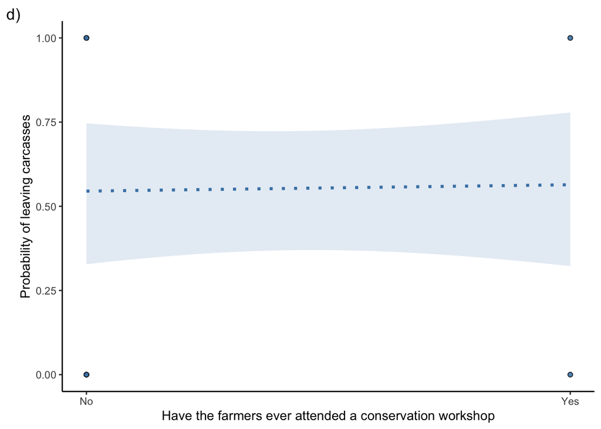

```r
newdat_leave_wor <- data.frame(
  workshop = seq(min(perceptions_coex$workshop),
                 max(perceptions_coex$workshop),
                 length = 100),
  perception = median(perceptions_coex$perception),
  pop.status = median(perceptions_coex$pop.status)
)

newdat_leave_per <- data.frame(
  workshop = median(perceptions_coex$workshop),
  perception = seq(min(perceptions_coex$perception),
                   max(perceptions_coex$perception),
                   length = 100),
  pop.status = median(perceptions_coex$pop.status)
)

newdat_leave_pop <- data.frame(
  workshop = median(perceptions_coex$workshop),
  perception = median(perceptions_coex$perception),
  pop.status = seq(min(perceptions_coex$pop.status),
                max(perceptions_coex$pop.status),
                length = 100)
)

# predictions from models
pred_leave_workshop <- make_pred_df(mods_leave$global, newdat_leave_wor, "workshop")
pred_leave_perception <- make_pred_df(mods_leave$perception, newdat_leave_per, "perception")
pred_leave_pop.status <- make_pred_df(mods_leave$global, newdat_leave_pop, "pop.status")

leave_a <- ggplot(pred_leave_workshop, aes(x = xvar, y = pred)) +
  geom_ribbon(aes(ymin = pred_low, ymax = pred_high),
              fill = "steelblue", alpha = 0.15) +
  geom_line(size = 1.2, color = "steelblue", linetype = "dotted") +
  geom_point(data = perceptions_coex,
             aes(x = workshop, y = leave),
             alpha = 0.2, shape = 21, fill = "steelblue") +
  scale_y_continuous(limits = c(0,1)) +
  scale_x_continuous(breaks = c(0,1),
                     labels = c("0" = "No", "1" = "Yes"))+
  labs(x = "Have the farmers ever attended a conservation workshop",
       y = "Probability of leaving carcasses",
       tag = "d)") +
  theme_classic()
leave_a
```

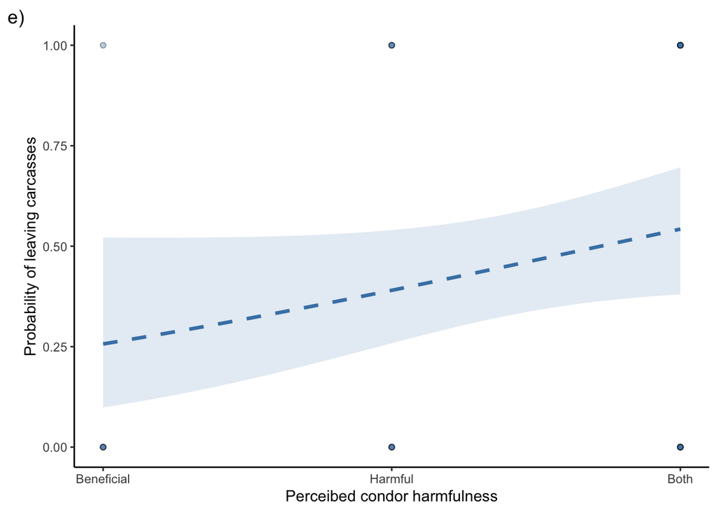

```r
leave_b <- ggplot(pred_leave_perception, aes(x = xvar, y = pred)) +
  geom_ribbon(aes(ymin = pred_low, ymax = pred_high),
              fill = "steelblue", alpha = 0.15) +
  geom_line(size = 1.2, color = "steelblue", linetype = "dashed") +
  geom_point(data = perceptions_coex,
             aes(x = perception, y = leave),
             alpha = 0.2, shape = 21, fill = "steelblue") +
  scale_y_continuous(limits = c(0,1)) +
  scale_x_continuous(breaks = c(0,1,2),
                     labels = c("0" = "Beneficial",
                                "1" = "Harmful",
                                "2" = "Both"))+
  labs(x = "Perceibed condor harmfulness",
       y = "Probability of leaving carcasses",
       tag = "e)") +
  theme_classic()
leave_b
```

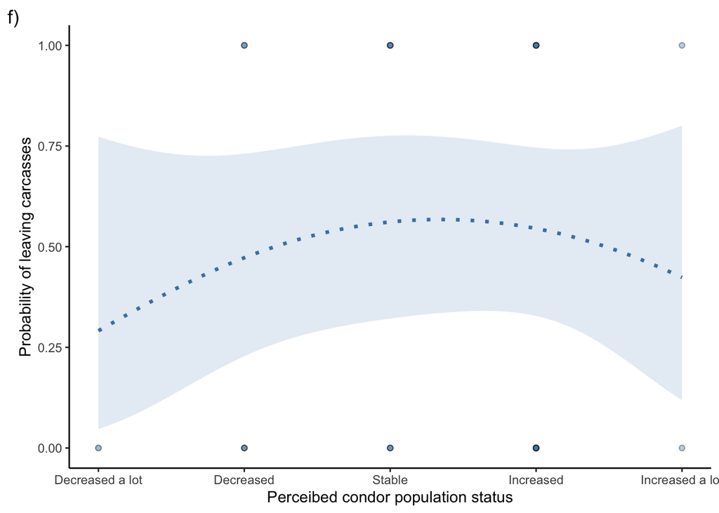

```r
leave_c <- ggplot(pred_leave_pop.status, aes(x = xvar, y = pred)) +
  geom_ribbon(aes(ymin = pred_low, ymax = pred_high),
              fill = "steelblue", alpha = 0.15) +
  geom_line(size = 1.2, color = "steelblue", linetype = "dotted") +
  geom_point(data = perceptions_coex,
             aes(x = pop.status, y = leave),
             alpha = 0.2, shape = 21, fill = "steelblue") +
  scale_y_continuous(limits = c(0,1)) +
  scale_x_continuous(breaks = c(0,1,2,3,4),
                     labels = c("0" = "Decreased a lot",
                                "1" = "Decreased",
                                "2" = "Stable",
                                "3" = "Increased",
                                "4" = "Increased a lot"))+
  labs(x = "Perceibed condor population status",
       y = "Probability of leaving carcasses",
       tag = "f)") +
  theme_classic()
leave_c
```

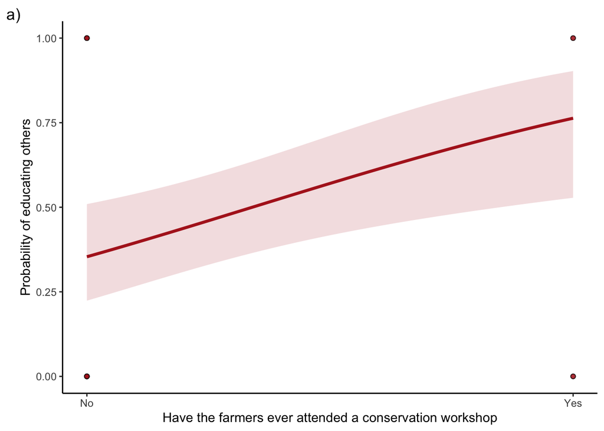

```r
pred_educa_workshop <- make_pred_df(mods_educate$workshop, newdat_leave_wor, "workshop")
pred_educa_perception <- make_pred_df(mods_educate$global, newdat_leave_per, "perception")
pred_educa_pop.status <- make_pred_df(mods_educate$global, newdat_leave_pop, "pop.status")

educa_a <- ggplot(pred_educa_workshop, aes(x = xvar, y = pred)) +
  geom_ribbon(aes(ymin = pred_low, ymax = pred_high),
              fill = "firebrick", alpha = 0.15) +
  geom_line(size = 1.2, color = "firebrick", linetype = "solid") +
  geom_point(data = perceptions_coex,
             aes(x = workshop, y = leave),
             alpha = 0.2, shape = 21, fill = "firebrick") +
  scale_y_continuous(limits = c(0,1)) +
  scale_x_continuous(breaks = c(0,1),
                     labels = c("0" = "No", "1" = "Yes"))+
  labs(x = "Have the farmers ever attended a conservation workshop",
       y = "Probability of educating others",
       tag = "a)") +
  theme_classic()
educa_a
```

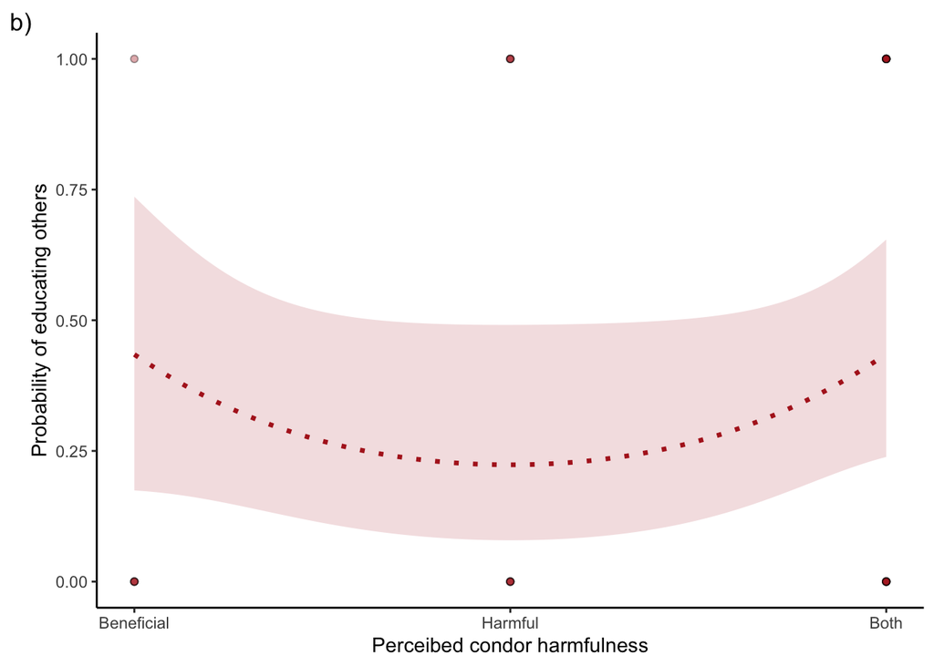

```r
educa_b <- ggplot(pred_educa_perception, aes(x = xvar, y = pred)) +
  geom_ribbon(aes(ymin = pred_low, ymax = pred_high),
              fill = "firebrick", alpha = 0.15) +
  geom_line(size = 1.2, color = "firebrick", linetype = "dotted") +
  geom_point(data = perceptions_coex,
             aes(x = perception, y = leave),
             alpha = 0.2, shape = 21, fill = "firebrick") +
  scale_y_continuous(limits = c(0,1)) +
  scale_x_continuous(breaks = c(0,1,2),
                     labels = c("0" = "Beneficial",
                                "1" = "Harmful",
                                "2" = "Both"))+
  labs(x = "Perceibed condor harmfulness",
       y = "Probability of educating others",
       tag = "b)") +
  theme_classic()
educa_b
```

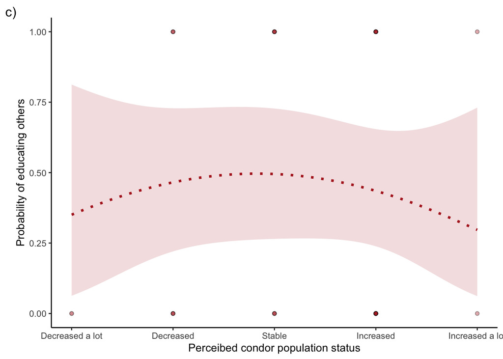

```r
educa_c <- ggplot(pred_educa_pop.status, aes(x = xvar, y = pred)) +
  geom_ribbon(aes(ymin = pred_low, ymax = pred_high),
              fill = "firebrick", alpha = 0.15) +
  geom_line(size = 1.2, color = "firebrick", linetype = "dotted") +
  geom_point(data = perceptions_coex,
             aes(x = pop.status, y = leave),
             alpha = 0.2, shape = 21, fill = "firebrick") +
  scale_y_continuous(limits = c(0,1)) +
  scale_x_continuous(breaks = c(0,1,2,3,4),
                     labels = c("0" = "Decreased a lot",
                                "1" = "Decreased",
                                "2" = "Stable",
                                "3" = "Increased",
                                "4" = "Increased a lot"))+
  labs(x = "Perceibed condor population status",
       y = "Probability of educating others",
       tag = "c)") +
  theme_classic()
educa_c
```

And combining the figure

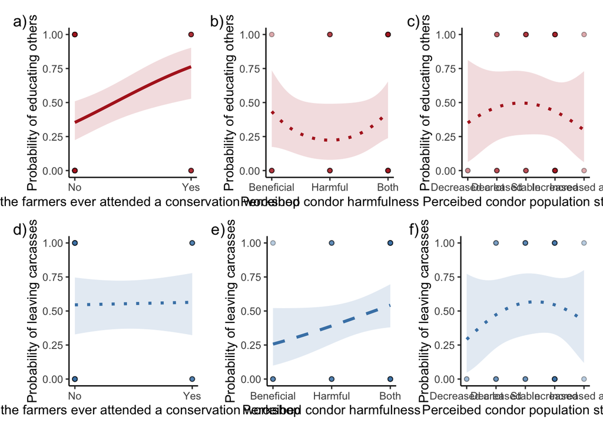

```r
(educa_a | educa_b | educa_c) / (leave_a | leave_b | leave_c)
```

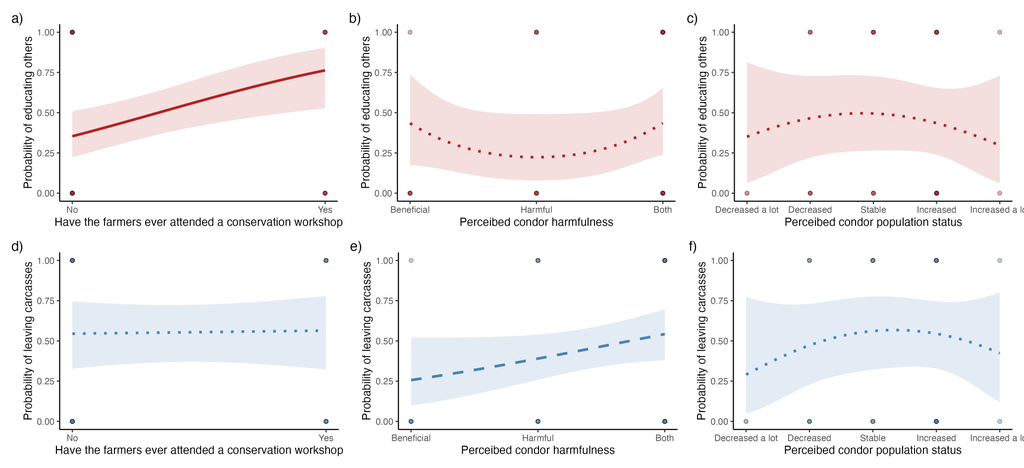

**Coexistence behavior require conservation action.** Educating others about Andean condor conservation clearly related with attendance to conservation workshops (training and talks). However, there were not clear relationship of the other predictors in this behavior of educating others or the behavior of leaving carcasses for Andean condor (dotted lines). The marginal trend of leaving carcases with perception of harmfulness was an exception.

```r
ggsave(filename = "figs/Fig_Aim3_Coexistence.jpg", dpi = 300,
       width = 350, height = 160, units = "mm")
```